# Linear Regression for Prediction

The goal of this notebook is to walk you through the mechanics of exploring complex datasets and designing a predictive model using linear regression.

The example we will use is [Lending Club](https://www.lendingclub.com) , a peer-to-peer lender. The goal is to come up with an algorithm that recommends the interest rate to charge to new loans. The lending club has made historical data publicly available and we will use it for this exercise.

## 0) Getting started with VSCode and Jupyter notebooks

**In the following, we assume that you have downloaded both VSCode and Uv using the instructions available at this [Tech Setup Link](https://www.notion.so/Data-Science-for-Business-Tech-Setup-Requirements-259c11fb2e308042b7e1d4b7924e2508).**

VSCode is quite intuitive to use, but it does require some time to get used to. In particular, make sure that you are familiare with the following!

1. First of all, make sure that you have opened the folder AM04 with VSCode.
2. Sync the project! Open the VSCode terminal, go on View > Terminal. In the terminal type uv sync.
3. This will create a virtual environment called AM04 which you will be using throughout the whole course. Here we will keep all the relevant data science packages.
4. Set the correct environment to run the notebook. In the top right corner of your screen you should already see the correct virtual environment called am04, see picture below. In this case, you are ready to run the code. Instead, if you see a "Select Kernel" command, then click on it, select Python Environments and, finally, click on am04 (it should also be recommended at the top!) **If VSCode prompts you to install suggested extensions Python+Jupyter, please click yes!**

[figure not shown]

## 1) Load the data

```python
# Localized imports for this section
import pandas as pd

df = pd.read_csv("LendingClub_Data.csv", skiprows=1, low_memory=False)
df.head()
```

|  | int_rate | loan_amnt | term (months) | installment | dti | delinq_2yrs | annual_inc | grade | emp_title | emp_length | ... | Unnamed: 70 | Unnamed: 71 | Unnamed: 72 | Unnamed: 73 | Unnamed: 74 | Unnamed: 75 | Unnamed: 76 | Unnamed: 77 | Unnamed: 78 | Unnamed: 79 |
| --- | --- | --- | --- | --- | --- | --- | --- | --- | --- | --- | --- | --- | --- | --- | --- | --- | --- | --- | --- | --- | --- |
| 0 | 0.05 | 8000 | 36.0 | 241.28 | 2.11 | 0.0 | 50000.0 | A | NaN | 5 years | ... | NaN | NaN | NaN | NaN | NaN | NaN | NaN | NaN | NaN | NaN |
| 1 | 0.05 | 6000 | 36.0 | 180.96 | 5.73 | 0.0 | 52800.0 | A | coral graphics | < 1 year | ... | NaN | NaN | NaN | NaN | NaN | NaN | NaN | NaN | NaN | NaN |
| 2 | 0.05 | 6500 | 36.0 | 196.04 | 17.68 | 0.0 | 35352.0 | A | NaN | NaN | ... | NaN | NaN | NaN | NaN | NaN | NaN | NaN | NaN | NaN | NaN |
| 3 | 0.05 | 8000 | 36.0 | 241.28 | 22.71 | 0.0 | 79200.0 | A | Honeywell | NaN | ... | NaN | NaN | NaN | NaN | NaN | NaN | NaN | NaN | NaN | NaN |
| 4 | 0.05 | 5500 | 36.0 | 165.88 | 5.75 | 0.0 | 240000.0 | A | O T Plus, Inc | 10+ years | ... | NaN | NaN | NaN | NaN | NaN | NaN | NaN | NaN | NaN | NaN |

5 rows × 80 columns

```python
df.shape
```

```
(42538, 80)
```

```python
df.describe()
```

|  | int_rate | term (months) | installment | dti | delinq_2yrs | annual_inc | Unnamed: 19 | Unnamed: 20 | Unnamed: 21 | Unnamed: 22 | ... | Unnamed: 70 | Unnamed: 71 | Unnamed: 72 | Unnamed: 73 | Unnamed: 74 | Unnamed: 75 | Unnamed: 76 | Unnamed: 77 | Unnamed: 78 | Unnamed: 79 |
| --- | --- | --- | --- | --- | --- | --- | --- | --- | --- | --- | --- | --- | --- | --- | --- | --- | --- | --- | --- | --- | --- |
| count | 37869.000000 | 37869.000000 | 37869.000000 | 37869.000000 | 37869.000000 | 3.786900e+04 | 0.0 | 0.0 | 0.0 | 0.0 | ... | 0.0 | 0.0 | 0.0 | 0.0 | 0.0 | 0.0 | 0.0 | 0.0 | 2660.0 | 2720.000000 |
| mean | 0.120264 | 42.461222 | 332.581354 | 13.284162 | 0.145554 | 6.914786e+04 | NaN | NaN | NaN | NaN | ... | NaN | NaN | NaN | NaN | NaN | NaN | NaN | NaN | 0.0 | 2.235294 |
| std | 0.037264 | 10.645418 | 214.289826 | 6.686636 | 0.491173 | 6.166703e+04 | NaN | NaN | NaN | NaN | ... | NaN | NaN | NaN | NaN | NaN | NaN | NaN | NaN | 0.0 | 116.061941 |
| min | 0.050000 | 36.000000 | 15.680000 | 0.000000 | 0.000000 | 4.000000e+03 | NaN | NaN | NaN | NaN | ... | NaN | NaN | NaN | NaN | NaN | NaN | NaN | NaN | 0.0 | 0.000000 |
| 25% | 0.090000 | 36.000000 | 168.590000 | 8.140000 | 0.000000 | 4.080000e+04 | NaN | NaN | NaN | NaN | ... | NaN | NaN | NaN | NaN | NaN | NaN | NaN | NaN | 0.0 | 0.000000 |
| 50% | 0.120000 | 36.000000 | 288.330000 | 13.360000 | 0.000000 | 5.953400e+04 | NaN | NaN | NaN | NaN | ... | NaN | NaN | NaN | NaN | NaN | NaN | NaN | NaN | 0.0 | 0.000000 |
| 75% | 0.150000 | 60.000000 | 449.050000 | 18.580000 | 0.000000 | 8.280000e+04 | NaN | NaN | NaN | NaN | ... | NaN | NaN | NaN | NaN | NaN | NaN | NaN | NaN | 0.0 | 0.000000 |
| max | 0.250000 | 60.000000 | 1305.190000 | 29.990000 | 11.000000 | 6.000000e+06 | NaN | NaN | NaN | NaN | ... | NaN | NaN | NaN | NaN | NaN | NaN | NaN | NaN | 0.0 | 6053.000000 |

8 rows × 67 columns

```python
df.dtypes
```

```
int_rate         float64
loan_amnt         object
term (months)    float64
installment      float64
dti              float64
                  ...
Unnamed: 75      float64
Unnamed: 76      float64
Unnamed: 77      float64
Unnamed: 78      float64
Unnamed: 79      float64
Length: 80, dtype: object
```

## 2) Quick cleaning of the data

```python
df_clean = df.iloc[:,:19]
df_clean = df_clean[ df_clean['int_rate'].notna() ]
df_clean['issue_d'] = pd.to_datetime(df_clean['issue_d'], format='%m/%d/%Y', errors='coerce')
df_clean['term'] = df_clean['term (months)'].astype('category')
df_clean['delinq_2yrs'] = df_clean['delinq_2yrs'].astype('category')
df_clean['loan_amnt'] = pd.to_numeric(df_clean['loan_amnt'], errors='coerce')
df_clean = df_clean.drop(columns=['emp_title', 'installment', 'term (months)'])
df_clean.head()
```

|  | int_rate | loan_amnt | dti | delinq_2yrs | annual_inc | grade | emp_length | home_ownership | verification_status | issue_d | zip_code | addr_state | loan_status | desc | purpose | title | term |
| --- | --- | --- | --- | --- | --- | --- | --- | --- | --- | --- | --- | --- | --- | --- | --- | --- | --- |
| 0 | 0.05 | 8000 | 2.11 | 0.0 | 50000.0 | A | 5 years | MORTGAGE | Verified | 2011-09-01 | 977xx | OR | Fully Paid | Borrower added on 09/08/11 > Consolidating d... | debt_consolidation | Credit Card Payoff $8K | 36.0 |
| 1 | 0.05 | 6000 | 5.73 | 0.0 | 52800.0 | A | < 1 year | MORTGAGE | Source Verified | 2011-09-01 | 228xx | VA | Charged Off | Borrower added on 09/08/11 > excellent credi... | vacation | bad choice | 36.0 |
| 2 | 0.05 | 6500 | 17.68 | 0.0 | 35352.0 | A | NaN | MORTGAGE | Not Verified | 2011-09-01 | 864xx | AZ | Fully Paid | Borrower added on 09/09/11 > I plan to use t... | credit_card | Credit Card Loan | 36.0 |
| 3 | 0.05 | 8000 | 22.71 | 0.0 | 79200.0 | A | NaN | MORTGAGE | Verified | 2011-09-01 | 322xx | FL | Fully Paid | Borrower added on 09/08/11 > Home improvemen... | home_improvement | Home Improvement | 36.0 |
| 4 | 0.05 | 5500 | 5.75 | 0.0 | 240000.0 | A | 10+ years | MORTGAGE | Source Verified | 2011-09-01 | 278xx | NC | Fully Paid | NaN | car | Car Loan | 36.0 |

```python
df_clean.dtypes
```

```
int_rate                      float64
loan_amnt                       int64
dti                           float64
delinq_2yrs                  category
annual_inc                    float64
grade                          object
emp_length                     object
home_ownership                 object
verification_status            object
issue_d                datetime64[ns]
zip_code                       object
addr_state                     object
loan_status                    object
desc                           object
purpose                        object
title                          object
term                         category
dtype: object
```

## 3) Exploratory Data Analysis

There are two main plotting libraries in Python. Matplotlib is the standard one. Here we will also use seaborn, which allows for creating more complex and beautiful plots.

```python
import seaborn as sns
from matplotlib import pyplot as plt
```

### Histograms

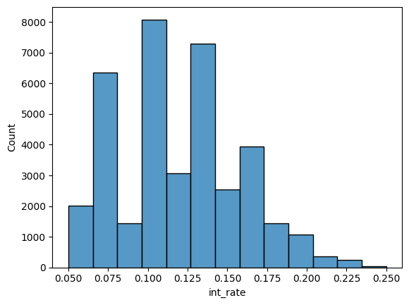

```python
# Histogram of interest rates
sns.histplot(data=df_clean,
             x='int_rate',
             binwidth=0.015)
```

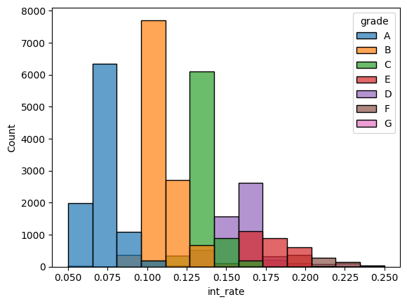

```python
sns.histplot(data=df_clean,
             x='int_rate',
             hue='grade',
             multiple='layer',
             alpha=0.7,
             binwidth=0.015)
```

### Density Plot

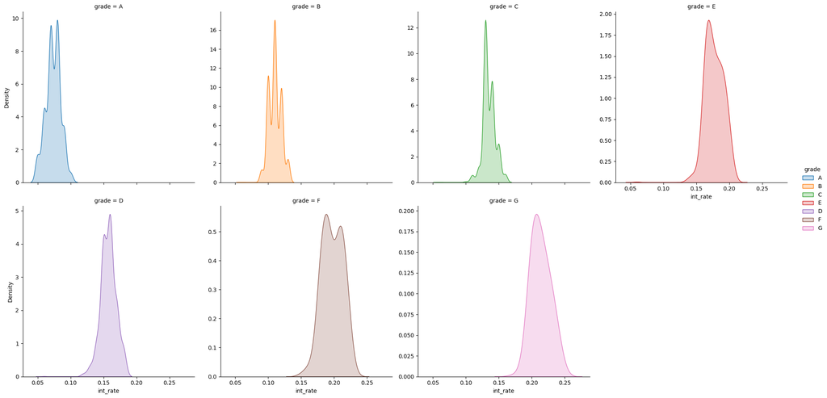

```python
sns.displot(
    data=df_clean,
    x="int_rate",
    hue="grade",         # give each grade its own color (like fill)
    kind="kde",
    bw_adjust= 2,
    fill=True,
    facet_kws={"sharey": False},  # so y-axis scales independently per facet
    col="grade",         # facet by grade
    col_wrap=4          # wrap into rows of 4 plots
)
```

### Box plots

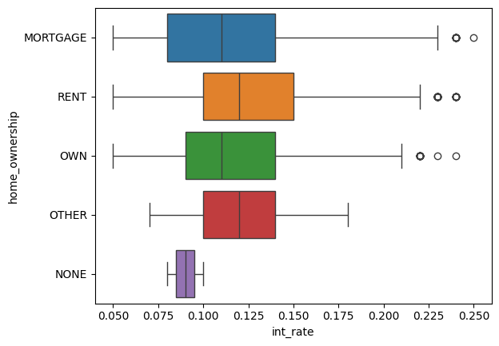

```python
sns.boxplot(
    data=df_clean,
    y="home_ownership",
    x="int_rate",
    hue="home_ownership",
    dodge=False,
)
```

### Scatter plot and regression lines

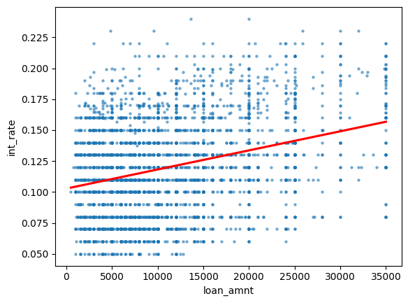

```python
df_sample = df_clean.iloc[::10, :] # subsample just for visualisation purposes
sns.regplot(
    data=df_sample,
    x="loan_amnt",
    y="int_rate",
    scatter_kws={"s": 5, "alpha": 0.5},  # size ~0.1 in ggplot
    line_kws={"color": "red"},           # regression line
    ci=None                              # se=0 (no confidence band)
)
```

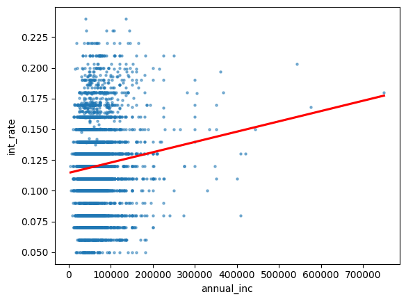

```python
sns.regplot(
    data=df_sample,
    x="annual_inc",
    y="int_rate",
    scatter_kws={"s": 5, "alpha": 0.5},  # size ~0.1 in ggplot
    line_kws={"color": "red"},           # regression line
    ci=None                              # se=0 (no confidence band)
)
```

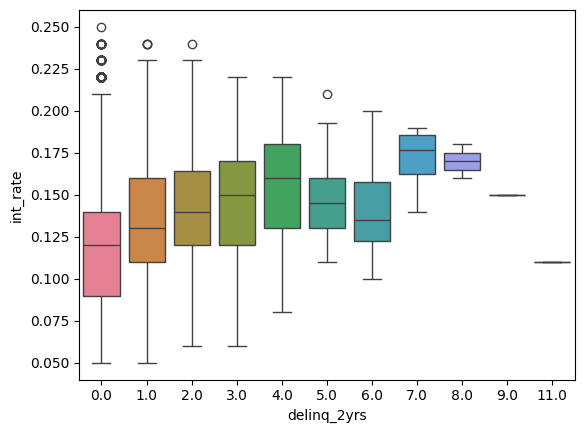

```python
sns.boxplot(
    data=df_clean,
    x="delinq_2yrs",
    y="int_rate",
    hue="delinq_2yrs",     # colour by delinq_2yrs
    dodge=False,
)
plt.legend([], [], frameon=False)
```

### Do delinquencies in the last two years impact interest rates?

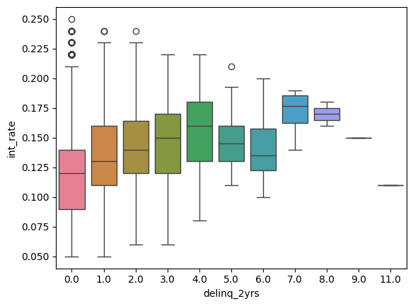

```python
sns.boxplot(
    data=df_clean,
    x="delinq_2yrs",
    y="int_rate",
    hue="delinq_2yrs"    # colour by delinq_2yrs
)
plt.legend([], [], frameon=False)
```

### Correlation Table

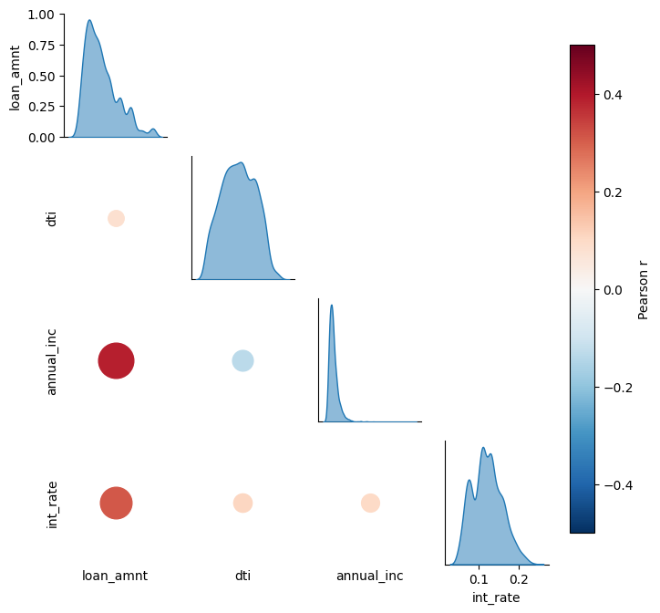

```python
import seaborn as sns, matplotlib.pyplot as plt, numpy as np
from matplotlib.colors import Normalize

vars_order = ['loan_amnt','dti','annual_inc','int_rate']
df_plot = df_clean.iloc[::10, :].copy()

# bubble plot for correlations
def corr_dot(x, y, **kws):
    ax = plt.gca()
    x, y = np.asarray(x, float), np.asarray(y, float)
    m = np.isfinite(x) & np.isfinite(y)
    r = 0.0 if m.sum() < 2 else np.corrcoef(x[m], y[m])[0, 1]
    # scatter bubble in middle of cell
    ax.scatter(0.5, 0.5, s=2000*abs(r), c=[[r]],
               cmap=kws["cmap"], norm=kws["norm"],
               transform=ax.transAxes)
    # clean ticks & spines but KEEP axis for labels
    ax.set_xticks([]); ax.set_yticks([])
    for spine in ax.spines.values(): spine.set_visible(False)

# hide upper triangle completely
def hide_axis(*args, **kwargs):
    plt.gca().set_visible(False)

g = sns.PairGrid(df_plot, vars=vars_order, diag_sharey=False, height=1.7)
# diagonal: filled KDE
g.map_diag(
    sns.kdeplot,
    fill=True, alpha=0.5
)
norm = Normalize(-0.5, 0.5)
g.map_lower(corr_dot, norm=norm, cmap="RdBu_r")
g.map_upper(hide_axis)

# labels for lower axes
for ax, lab in zip(g.axes[-1, :], vars_order): ax.set_xlabel(lab)
for ax, lab in zip(g.axes[:, 0], vars_order):  ax.set_ylabel(lab)

# colorbar
sm = plt.cm.ScalarMappable(norm=norm, cmap="RdBu_r"); sm.set_array([])
g.fig.colorbar(sm, ax=g.axes, fraction=0.046, pad=0.04, label="Pearson r")

plt.show()
```

## 4) Linear Regression

```python
import numpy as np
import statsmodels.formula.api as smf
```

Define a function to get some stats: residual standard error, residual degreees of freedom.

```python
def get_stats(model):
    # residual standard error (Root MSE)
    rse = np.sqrt(model.mse_resid)
    # degrees of freedom of the model
    df_resid = int(model.df_resid)
    return rse, df_resid
```

### The simplest linear regression: fitting the mean to the data

```python
model0 = smf.ols('int_rate ~ 1', data=df_clean).fit()
print(model0.summary())
```

```
                            OLS Regression Results
==============================================================================
Dep. Variable:               int_rate   R-squared:                      -0.000
Model:                            OLS   Adj. R-squared:                 -0.000
Method:                 Least Squares   F-statistic:                       nan
Date:                Wed, 30 Sep 2026   Prob (F-statistic):                nan
Time:                        19:51:29   Log-Likelihood:                 70845.
No. Observations:               37869   AIC:                        -1.417e+05
Df Residuals:                   37868   BIC:                        -1.417e+05
Df Model:                           0
Covariance Type:            nonrobust
==============================================================================
                 coef    std err          t      P>|t|      [0.025      0.975]
------------------------------------------------------------------------------
Intercept      0.1203      0.000    628.034      0.000       0.120       0.121
==============================================================================
Omnibus:                      972.461   Durbin-Watson:                   0.000
Prob(Omnibus):                  0.000   Jarque-Bera (JB):              816.859
Skew:                           0.292   Prob(JB):                    4.18e-178
Kurtosis:                       2.580   Cond. No.                         1.00
==============================================================================

Notes:
[1] Standard Errors assume that the covariance matrix of the errors is correctly specified.
```

```python
rse_val, df_resid_val = get_stats(model0)
print(f"\nResidual standard error: {rse_val:.4f} on {df_resid_val} degrees of freedom")
```

```
Residual standard error: 0.0373 on 37868 degrees of freedom
```

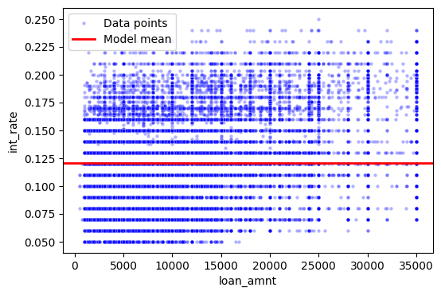

```python
plt.figure(figsize=(6,4))
# Scatter plot
sns.scatterplot(x=df_clean["loan_amnt"], y=df_clean['int_rate'], alpha=0.3, s=10, color="blue", label="Data points")

# Model mean as horizontal line
plt.axhline(model0.params.iloc[0], color="red", linewidth=2, label="Model mean")
plt.legend()
```

### Univariate linear regression: using loan_amnt as a predictor

```python
model1 = smf.ols('int_rate ~ loan_amnt', data=df_clean).fit()
print(model1.summary())
```

```
                            OLS Regression Results
==============================================================================
Dep. Variable:               int_rate   R-squared:                       0.097
Model:                            OLS   Adj. R-squared:                  0.097
Method:                 Least Squares   F-statistic:                     4067.
Date:                Wed, 30 Sep 2026   Prob (F-statistic):               0.00
Time:                        19:51:36   Log-Likelihood:                 72776.
No. Observations:               37869   AIC:                        -1.455e+05
Df Residuals:                   37867   BIC:                        -1.455e+05
Df Model:                           1
Covariance Type:            nonrobust
==============================================================================
                 coef    std err          t      P>|t|      [0.025      0.975]
------------------------------------------------------------------------------
Intercept      0.1028      0.000    312.155      0.000       0.102       0.103
loan_amnt   1.555e-06   2.44e-08     63.770      0.000    1.51e-06     1.6e-06
==============================================================================
Omnibus:                     1206.933   Durbin-Watson:                   0.180
Prob(Omnibus):                  0.000   Jarque-Bera (JB):              751.554
Skew:                           0.211   Prob(JB):                    6.34e-164
Kurtosis:                       2.453   Cond. No.                     2.44e+04
==============================================================================

Notes:
[1] Standard Errors assume that the covariance matrix of the errors is correctly specified.
[2] The condition number is large, 2.44e+04. This might indicate that there are
strong multicollinearity or other numerical problems.
```

```python
rse_val, df_resid_val = get_stats(model1)
print(f"\nResidual standard error: {rse_val:.4f} on {df_resid_val} degrees of freedom")
```

```
Residual standard error: 0.0354 on 37867 degrees of freedom
```

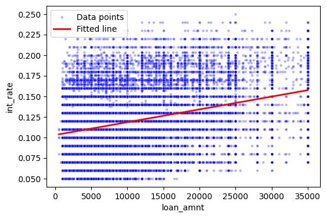

```python
plt.figure(figsize=(6,4))
# Scatter plot
x=df_clean["loan_amnt"]
y=df_clean['int_rate']

sns.scatterplot(x=x, y=y, alpha=0.3, s=10, color="blue", label="Data points")

# x range for predictions
x_vals = np.linspace(x.min(), x.max(), 200)

# build DataFrame with the predictor name matching the formula
X_pred = pd.DataFrame({'loan_amnt': x_vals})

# use model.predict on this DataFrame
y_pred = model1.predict(X_pred)

# plot
plt.plot(x_vals, y_pred, color="red", linewidth=2, label="Fitted line")
plt.legend()
```

```python
from statsmodels.stats.anova import anova_lm
anova_res = anova_lm(model0, model1)  # order: smaller, then larger model
print(anova_res)
```

```
   df_resid        ssr  df_diff   ss_diff            F  Pr(>F)
0   37868.0  52.584888      0.0       NaN          NaN     NaN
1   37867.0  47.485333      1.0  5.099555  4066.621006     0.0
```

## Feature Engineering

We can improve the explanatory power of the model by adding features. This process, sometimes called “Feature Engineering”, is more of an art that it is science. Below is a non-exhaustive list of ways in which we engineer features.

- Add features directly from the dataset. Some of these features are numerical (e.g., dti, annual income) – in this case the estimated coefficient 𝛽 has the interpretation of 1 unit of increase in the feature will create 𝛽 units of increase in 𝑦. Some are categorical (factor) variables (e.g. term, grade) – in this case the estimated coefficient of one category measures the average difference in variable y between the category and the omitted category.
- Add interaction terms. There are three possibilities – interactions between two categorical variables, one categorical and one numerical variable, two numerical variables. For example, if we believe the loan amount affects the interest rate of 36-month loans more than it does of 60-month loans then this is an interaction hypothesis between a continuous variable (the loan amount) and a categorical variable (the term). Make sure you understand how to interpret these. In R we can add interactions between var1 and var2 by writing 𝑦∼𝑣𝑎𝑟1∗𝑣𝑎𝑟2.
- Add non-linear terms. Sometimes we believe that the effect of a feature on the variable we are trying to predict is non linear. For example, we may believe that a small increase in the loan amount does not affect the interest rate by much, but a larger increase will have a larger impact. We can test this by adding higher powers of the variable to the model. Or we may want to do any other non linear transformation (e.g., taking logarithms to reduce the spread of the variable or using the inverse of a variable to denote an inversely proportional relationship). The estimated coefficient has the same interpretation as the liner model but now applied to the non-linear transformation of the feature.

In addition to the transformations, we may want to break a continuous variable into a set of dummy variables, e.g., low loan_amnt, med loan_amnt, high loan_amnt, or the deciles of the loan amount. This is a way to allow loan_amnt to have a non-linear impact on the interest rate. Because we don’t specify a specific parametric form that this impact will take, this way of capturing non-linear effects is sometimes called non-parametric.

When we compare models with a different set of features we want to choose the model that has the best explanatory power (e.g., higher R square or lowest RMSE). More on this later.

## 4. Multiple Linear Regression Models

```python
# Model 1 with categorical variable (term)
model1a = smf.ols('int_rate ~ loan_amnt + C(term) + dti + annual_inc', data=df_clean).fit()
print(model1a.summary())
```

```
                            OLS Regression Results
==============================================================================
Dep. Variable:               int_rate   R-squared:                       0.233
Model:                            OLS   Adj. R-squared:                  0.233
Method:                 Least Squares   F-statistic:                     2875.
Date:                Wed, 30 Sep 2026   Prob (F-statistic):               0.00
Time:                        19:51:47   Log-Likelihood:                 75867.
No. Observations:               37869   AIC:                        -1.517e+05
Df Residuals:                   37864   BIC:                        -1.517e+05
Df Model:                           4
Covariance Type:            nonrobust
===================================================================================
                      coef    std err          t      P>|t|      [0.025      0.975]
-----------------------------------------------------------------------------------
Intercept           0.0971      0.000    205.967      0.000       0.096       0.098
C(term)[T.60.0]     0.0323      0.000     79.269      0.000       0.031       0.033
loan_amnt        8.384e-07   2.52e-08     33.261      0.000    7.89e-07    8.88e-07
dti                 0.0004   2.55e-05     15.040      0.000       0.000       0.000
annual_inc       -1.84e-10   2.87e-09     -0.064      0.949   -5.81e-09    5.44e-09
==============================================================================
Omnibus:                     1672.837   Durbin-Watson:                   0.363
Prob(Omnibus):                  0.000   Jarque-Bera (JB):              794.572
Skew:                           0.147   Prob(JB):                    2.89e-173
Kurtosis:                       2.354   Cond. No.                     2.62e+05
==============================================================================

Notes:
[1] Standard Errors assume that the covariance matrix of the errors is correctly specified.
[2] The condition number is large, 2.62e+05. This might indicate that there are
strong multicollinearity or other numerical problems.
```

```python
rse_val, df_resid_val = get_stats(model1a)
print(f"\nResidual standard error: {rse_val:.4f} on {df_resid_val} degrees of freedom")
```

```
Residual standard error: 0.0326 on 37864 degrees of freedom
```

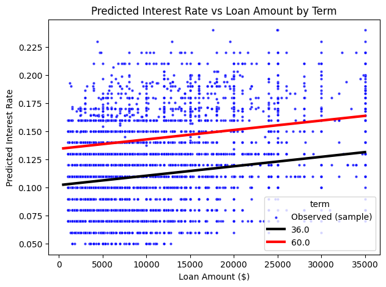

```python
# Plotting the model

# 2. Get all unique term levels
term_levels = df_clean['term'].cat.categories

# 3. Build prediction DataFrame: all loan_amnt × term combos
pred_data = pd.DataFrame({
    'loan_amnt': np.repeat(x_vals, len(term_levels)),
    'term': np.tile(term_levels, len(x_vals)),
    'dti': df_clean['dti'].mean(),           # hold other vars at mean
    'annual_inc': df_clean['annual_inc'].mean()
})

# 4. Predict from model
pred_data['int_rate_pred'] = model1a.predict(pred_data)

# 5. Plot
plt.figure(figsize=(7,5))

sns.scatterplot(data=df_clean.sample(5000), x='loan_amnt', y='int_rate',
                alpha=0.8, s=10, color="b", label="Observed (sample)")
palette = ["black", "red"]
sns.lineplot(data=pred_data, x='loan_amnt', y='int_rate_pred', hue='term', linewidth=3, alpha=1,palette=palette)

plt.xlabel("Loan Amount ($)")
plt.ylabel("Predicted Interest Rate")
plt.title("Predicted Interest Rate vs Loan Amount by Term")
plt.show()
```

```python
# Model 1 with interaction loan_amnt * term (continuos * categorical)
model1b = smf.ols(
    'int_rate ~ loan_amnt * C(term) + dti + annual_inc',
    data=df_clean
).fit()

print(model1b.summary())
```

```
                            OLS Regression Results
==============================================================================
Dep. Variable:               int_rate   R-squared:                       0.234
Model:                            OLS   Adj. R-squared:                  0.233
Method:                 Least Squares   F-statistic:                     2308.
Date:                Wed, 30 Sep 2026   Prob (F-statistic):               0.00
Time:                        19:51:58   Log-Likelihood:                 75881.
No. Observations:               37869   AIC:                        -1.518e+05
Df Residuals:                   37863   BIC:                        -1.517e+05
Df Model:                           5
Covariance Type:            nonrobust
=============================================================================================
                                coef    std err          t      P>|t|      [0.025      0.975]
---------------------------------------------------------------------------------------------
Intercept                     0.0981      0.001    193.575      0.000       0.097       0.099
C(term)[T.60.0]               0.0288      0.001     37.377      0.000       0.027       0.030
loan_amnt                  7.337e-07    3.2e-08     22.924      0.000    6.71e-07    7.96e-07
loan_amnt:C(term)[T.60.0]  2.615e-07   4.93e-08      5.306      0.000    1.65e-07    3.58e-07
dti                           0.0004   2.55e-05     15.012      0.000       0.000       0.000
annual_inc                 2.614e-10   2.87e-09      0.091      0.927   -5.36e-09    5.89e-09
==============================================================================
Omnibus:                     1692.021   Durbin-Watson:                   0.363
Prob(Omnibus):                  0.000   Jarque-Bera (JB):              798.816
Skew:                           0.147   Prob(JB):                    3.46e-174
Kurtosis:                       2.352   Cond. No.                     4.42e+05
==============================================================================

Notes:
[1] Standard Errors assume that the covariance matrix of the errors is correctly specified.
[2] The condition number is large, 4.42e+05. This might indicate that there are
strong multicollinearity or other numerical problems.
```

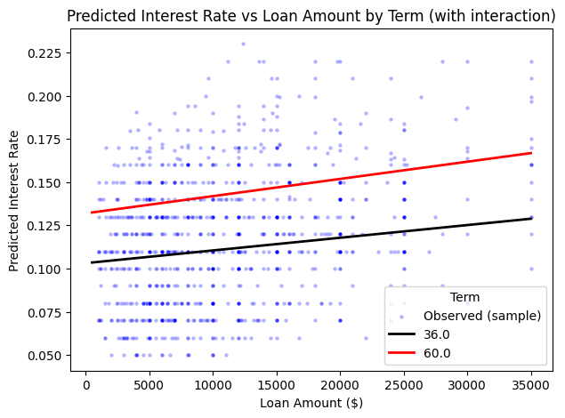

```python
# 3. Build prediction DataFrame: loan_amnt × term
pred_data = pd.DataFrame({
    'loan_amnt': np.repeat(x_vals, len(term_levels)),
    'term': np.tile(term_levels, len(x_vals)),
    'dti': df_clean['dti'].mean(),
    'annual_inc': df_clean['annual_inc'].mean()
})

# 4. Predict from the interaction model
pred_data['int_rate_pred'] = model1b.predict(pred_data)

# 5. Plot
plt.figure(figsize=(7,5))

# observed scatter: blue points
sns.scatterplot(
    data=df_clean.sample(1000, random_state=1),
    x='loan_amnt', y='int_rate',
    alpha=0.3, s=10, color="blue", label="Observed (sample)"
)

# fitted lines: black and red for terms
palette = ["black", "red"]
sns.lineplot(
    data=pred_data,
    x='loan_amnt', y='int_rate_pred',
    hue='term', linewidth=2, alpha=1,
    palette=palette
)

plt.xlabel("Loan Amount ($)")
plt.ylabel("Predicted Interest Rate")
plt.title("Predicted Interest Rate vs Loan Amount by Term (with interaction)")
plt.legend(title="Term")
plt.show()
```

```python
# Model 2: add grade as an extra categorical predictor
model2 = smf.ols(
    'int_rate ~ loan_amnt + C(term) + dti + annual_inc + C(grade)',
    data=df_clean
).fit()

print(model2.summary())
```

```
                            OLS Regression Results
==============================================================================
Dep. Variable:               int_rate   R-squared:                       0.920
Model:                            OLS   Adj. R-squared:                  0.920
Method:                 Least Squares   F-statistic:                 4.340e+04
Date:                Wed, 30 Sep 2026   Prob (F-statistic):               0.00
Time:                        19:52:07   Log-Likelihood:             1.1861e+05
No. Observations:               37869   AIC:                        -2.372e+05
Df Residuals:                   37858   BIC:                        -2.371e+05
Df Model:                          10
Covariance Type:            nonrobust
===================================================================================
                      coef    std err          t      P>|t|      [0.025      0.975]
-----------------------------------------------------------------------------------
Intercept           0.0717      0.000    424.363      0.000       0.071       0.072
C(term)[T.60.0]     0.0036      0.000     25.431      0.000       0.003       0.004
C(grade)[T.B]       0.0355      0.000    238.248      0.000       0.035       0.036
C(grade)[T.C]       0.0602      0.000    362.783      0.000       0.060       0.060
C(grade)[T.D]       0.0817      0.000    428.746      0.000       0.081       0.082
C(grade)[T.E]       0.1000      0.000    402.660      0.000       0.099       0.100
C(grade)[T.F]       0.1195      0.000    325.408      0.000       0.119       0.120
C(grade)[T.G]       0.1355      0.001    218.245      0.000       0.134       0.137
loan_amnt        1.475e-07   8.28e-09     17.809      0.000    1.31e-07    1.64e-07
dti              4.328e-05   8.27e-06      5.234      0.000    2.71e-05    5.95e-05
annual_inc      -9.734e-10   9.28e-10     -1.049      0.294   -2.79e-09    8.46e-10
==============================================================================
Omnibus:                     2515.011   Durbin-Watson:                   0.106
Prob(Omnibus):                  0.000   Jarque-Bera (JB):             9785.045
Skew:                          -0.234   Prob(JB):                         0.00
Kurtosis:                       5.446   Cond. No.                     1.08e+06
==============================================================================

Notes:
[1] Standard Errors assume that the covariance matrix of the errors is correctly specified.
[2] The condition number is large, 1.08e+06. This might indicate that there are
strong multicollinearity or other numerical problems.
```

```python
# Model3: includes interaction between loan_amnt and grade
model3 = smf.ols(
    'int_rate ~ loan_amnt * C(grade) + C(term) + dti + annual_inc',
    data=df_clean
).fit()

print(model3.summary())
```

```
                            OLS Regression Results
==============================================================================
Dep. Variable:               int_rate   R-squared:                       0.920
Model:                            OLS   Adj. R-squared:                  0.920
Method:                 Least Squares   F-statistic:                 2.735e+04
Date:                Wed, 30 Sep 2026   Prob (F-statistic):               0.00
Time:                        19:52:10   Log-Likelihood:             1.1876e+05
No. Observations:               37869   AIC:                        -2.375e+05
Df Residuals:                   37852   BIC:                        -2.373e+05
Df Model:                          16
Covariance Type:            nonrobust
===========================================================================================
                              coef    std err          t      P>|t|      [0.025      0.975]
-------------------------------------------------------------------------------------------
Intercept                   0.0717      0.000    305.762      0.000       0.071       0.072
C(grade)[T.B]               0.0362      0.000    132.619      0.000       0.036       0.037
C(grade)[T.C]               0.0620      0.000    207.452      0.000       0.061       0.063
C(grade)[T.D]               0.0808      0.000    232.034      0.000       0.080       0.081
C(grade)[T.E]               0.0963      0.000    208.293      0.000       0.095       0.097
C(grade)[T.F]               0.1143      0.001    147.699      0.000       0.113       0.116
C(grade)[T.G]               0.1327      0.002     85.580      0.000       0.130       0.136
C(term)[T.60.0]             0.0038      0.000     26.636      0.000       0.004       0.004
loan_amnt                1.528e-07   2.03e-08      7.537      0.000    1.13e-07    1.93e-07
loan_amnt:C(grade)[T.B] -6.617e-08   2.44e-08     -2.710      0.007   -1.14e-07   -1.83e-08
loan_amnt:C(grade)[T.C] -1.704e-07   2.62e-08     -6.500      0.000   -2.22e-07   -1.19e-07
loan_amnt:C(grade)[T.D]  6.703e-08    2.8e-08      2.395      0.017    1.22e-08    1.22e-07
loan_amnt:C(grade)[T.E]  2.209e-07   3.02e-08      7.323      0.000    1.62e-07     2.8e-07
loan_amnt:C(grade)[T.F]  2.779e-07   4.14e-08      6.720      0.000    1.97e-07    3.59e-07
loan_amnt:C(grade)[T.G]  1.265e-07   7.26e-08      1.743      0.081   -1.58e-08    2.69e-07
dti                      3.836e-05   8.25e-06      4.649      0.000    2.22e-05    5.45e-05
annual_inc              -1.224e-09   9.25e-10     -1.324      0.186   -3.04e-09    5.89e-10
==============================================================================
Omnibus:                     2531.136   Durbin-Watson:                   0.117
Prob(Omnibus):                  0.000   Jarque-Bera (JB):             9915.784
Skew:                          -0.235   Prob(JB):                         0.00
Kurtosis:                       5.463   Cond. No.                     2.68e+06
==============================================================================

Notes:
[1] Standard Errors assume that the covariance matrix of the errors is correctly specified.
[2] The condition number is large, 2.68e+06. This might indicate that there are
strong multicollinearity or other numerical problems.
```

```python
# Model4: quadratic polynomial and interactionss of loan amount and term with grade
model4 = smf.ols(
    'int_rate ~ loan_amnt * C(grade) + I(loan_amnt ** 2) + C(term) + C(term):C(grade) + dti + annual_inc',
    data=df_clean
).fit()

print(model4.summary())
```

```
                            OLS Regression Results
==============================================================================
Dep. Variable:               int_rate   R-squared:                       0.922
Model:                            OLS   Adj. R-squared:                  0.922
Method:                 Least Squares   F-statistic:                 1.949e+04
Date:                Wed, 30 Sep 2026   Prob (F-statistic):               0.00
Time:                        19:52:13   Log-Likelihood:             1.1918e+05
No. Observations:               37869   AIC:                        -2.383e+05
Df Residuals:                   37845   BIC:                        -2.381e+05
Df Model:                          23
Covariance Type:            nonrobust
=================================================================================================
                                    coef    std err          t      P>|t|      [0.025      0.975]
-------------------------------------------------------------------------------------------------
Intercept                         0.0725      0.000    292.676      0.000       0.072       0.073
C(grade)[T.B]                     0.0366      0.000    134.396      0.000       0.036       0.037
C(grade)[T.C]                     0.0622      0.000    209.383      0.000       0.062       0.063
C(grade)[T.D]                     0.0803      0.000    227.707      0.000       0.080       0.081
C(grade)[T.E]                     0.0942      0.001    182.244      0.000       0.093       0.095
C(grade)[T.F]                     0.1091      0.001    117.183      0.000       0.107       0.111
C(grade)[T.G]                     0.1283      0.002     68.822      0.000       0.125       0.132
C(term)[T.60.0]                   0.0021      0.001      3.934      0.000       0.001       0.003
C(term)[T.60.0]:C(grade)[T.B]    -0.0020      0.001     -3.439      0.001      -0.003      -0.001
C(term)[T.60.0]:C(grade)[T.C]     0.0001      0.001      0.180      0.857      -0.001       0.001
C(term)[T.60.0]:C(grade)[T.D]     0.0059      0.001      9.574      0.000       0.005       0.007
C(term)[T.60.0]:C(grade)[T.E]     0.0074      0.001     10.717      0.000       0.006       0.009
C(term)[T.60.0]:C(grade)[T.F]     0.0115      0.001     11.624      0.000       0.010       0.013
C(term)[T.60.0]:C(grade)[T.G]     0.0102      0.002      6.233      0.000       0.007       0.013
loan_amnt                     -8.783e-09   2.84e-08     -0.309      0.757   -6.45e-08    4.69e-08
loan_amnt:C(grade)[T.B]       -3.382e-08   2.47e-08     -1.372      0.170   -8.21e-08    1.45e-08
loan_amnt:C(grade)[T.C]       -1.643e-07   2.68e-08     -6.125      0.000   -2.17e-07   -1.12e-07
loan_amnt:C(grade)[T.D]       -3.713e-08   2.84e-08     -1.305      0.192   -9.29e-08    1.86e-08
loan_amnt:C(grade)[T.E]        8.072e-08   3.15e-08      2.563      0.010     1.9e-08    1.42e-07
loan_amnt:C(grade)[T.F]        9.681e-08   4.29e-08      2.256      0.024    1.27e-08    1.81e-07
loan_amnt:C(grade)[T.G]       -3.262e-08   7.36e-08     -0.444      0.657   -1.77e-07    1.12e-07
I(loan_amnt ** 2)              6.612e-12   8.02e-13      8.245      0.000    5.04e-12    8.18e-12
dti                            4.107e-05   8.17e-06      5.025      0.000    2.51e-05    5.71e-05
annual_inc                    -1.364e-09   9.15e-10     -1.490      0.136   -3.16e-09     4.3e-10
==============================================================================
Omnibus:                     2652.510   Durbin-Watson:                   0.128
Prob(Omnibus):                  0.000   Jarque-Bera (JB):            11077.860
Skew:                          -0.230   Prob(JB):                         0.00
Kurtosis:                       5.609   Cond. No.                     1.23e+10
==============================================================================

Notes:
[1] Standard Errors assume that the covariance matrix of the errors is correctly specified.
[2] The condition number is large, 1.23e+10. This might indicate that there are
strong multicollinearity or other numerical problems.
```

```python
# Create decile categorical variable for loan amount
df_clean['loan_amnt_decile'] = pd.qcut(df_clean['loan_amnt'], q=10, labels=False, duplicates='drop') + 1
df_clean['loan_amnt_decile'] = df_clean['loan_amnt_decile'].astype('category')

# Add decile dummies
model5 = smf.ols(
    'int_rate ~ loan_amnt * C(grade) + I(loan_amnt ** 2) + C(term) + C(term):C(grade) + dti + annual_inc + C(loan_amnt_decile)',
    data=df_clean
).fit()

print(model5.summary())
```

```
                            OLS Regression Results
==============================================================================
Dep. Variable:               int_rate   R-squared:                       0.922
Model:                            OLS   Adj. R-squared:                  0.922
Method:                 Least Squares   F-statistic:                 1.402e+04
Date:                Wed, 30 Sep 2026   Prob (F-statistic):               0.00
Time:                        19:52:18   Log-Likelihood:             1.1921e+05
No. Observations:               37869   AIC:                        -2.383e+05
Df Residuals:                   37836   BIC:                        -2.381e+05
Df Model:                          32
Covariance Type:            nonrobust
=================================================================================================
                                    coef    std err          t      P>|t|      [0.025      0.975]
-------------------------------------------------------------------------------------------------
Intercept                         0.0728      0.000    186.581      0.000       0.072       0.074
C(grade)[T.B]                     0.0364      0.000    133.750      0.000       0.036       0.037
C(grade)[T.C]                     0.0621      0.000    208.839      0.000       0.062       0.063
C(grade)[T.D]                     0.0802      0.000    227.176      0.000       0.079       0.081
C(grade)[T.E]                     0.0941      0.001    182.087      0.000       0.093       0.095
C(grade)[T.F]                     0.1092      0.001    117.163      0.000       0.107       0.111
C(grade)[T.G]                     0.1284      0.002     68.875      0.000       0.125       0.132
C(term)[T.60.0]                   0.0020      0.001      3.855      0.000       0.001       0.003
C(loan_amnt_decile)[T.2]         -0.0004      0.000     -1.182      0.237      -0.001       0.000
C(loan_amnt_decile)[T.3]         -0.0002      0.000     -0.414      0.679      -0.001       0.001
C(loan_amnt_decile)[T.4]         -0.0006      0.001     -0.927      0.354      -0.002       0.001
C(loan_amnt_decile)[T.5]         -0.0004      0.001     -0.557      0.578      -0.002       0.001
C(loan_amnt_decile)[T.6]         -0.0004      0.001     -0.405      0.686      -0.002       0.002
C(loan_amnt_decile)[T.7]       -4.72e-05      0.001     -0.043      0.966      -0.002       0.002
C(loan_amnt_decile)[T.8]         -0.0005      0.001     -0.448      0.654      -0.003       0.002
C(loan_amnt_decile)[T.9]         -0.0010      0.001     -0.705      0.481      -0.004       0.002
C(loan_amnt_decile)[T.10]        -0.0030      0.002     -1.849      0.065      -0.006       0.000
C(term)[T.60.0]:C(grade)[T.B]    -0.0020      0.001     -3.476      0.001      -0.003      -0.001
C(term)[T.60.0]:C(grade)[T.C]     0.0002      0.001      0.271      0.786      -0.001       0.001
C(term)[T.60.0]:C(grade)[T.D]     0.0058      0.001      9.461      0.000       0.005       0.007
C(term)[T.60.0]:C(grade)[T.E]     0.0074      0.001     10.737      0.000       0.006       0.009
C(term)[T.60.0]:C(grade)[T.F]     0.0114      0.001     11.496      0.000       0.009       0.013
C(term)[T.60.0]:C(grade)[T.G]     0.0101      0.002      6.130      0.000       0.007       0.013
loan_amnt                     -2.969e-08   1.33e-07     -0.223      0.823   -2.91e-07    2.31e-07
loan_amnt:C(grade)[T.B]       -2.065e-08   2.48e-08     -0.833      0.405   -6.92e-08     2.8e-08
loan_amnt:C(grade)[T.C]       -1.548e-07   2.69e-08     -5.752      0.000   -2.08e-07   -1.02e-07
loan_amnt:C(grade)[T.D]       -2.168e-08   2.86e-08     -0.758      0.448   -7.77e-08    3.44e-08
loan_amnt:C(grade)[T.E]        8.801e-08   3.15e-08      2.792      0.005    2.62e-08     1.5e-07
loan_amnt:C(grade)[T.F]        1.083e-07   4.29e-08      2.523      0.012    2.42e-08    1.92e-07
loan_amnt:C(grade)[T.G]       -1.907e-08   7.36e-08     -0.259      0.795   -1.63e-07    1.25e-07
I(loan_amnt ** 2)              9.981e-12   2.46e-12      4.054      0.000    5.16e-12    1.48e-11
dti                            3.995e-05   8.19e-06      4.880      0.000    2.39e-05     5.6e-05
annual_inc                    -1.292e-09   9.15e-10     -1.412      0.158   -3.09e-09    5.02e-10
==============================================================================
Omnibus:                     2654.082   Durbin-Watson:                   0.131
Prob(Omnibus):                  0.000   Jarque-Bera (JB):            11101.523
Skew:                          -0.230   Prob(JB):                         0.00
Kurtosis:                       5.612   Cond. No.                     1.71e+10
==============================================================================

Notes:
[1] Standard Errors assume that the covariance matrix of the errors is correctly specified.
[2] The condition number is large, 1.71e+10. This might indicate that there are
strong multicollinearity or other numerical problems.
```

```python
anova_lm(model1, model2, model3, model4, model5)
```

|  | df_resid | ssr | df_diff | ss_diff | F | Pr(>F) |
| --- | --- | --- | --- | --- | --- | --- |
| 0 | 37867.0 | 47.485333 | 0.0 | NaN | NaN | NaN |
| 1 | 37858.0 | 4.219195 | 9.0 | 43.266138 | 44481.186030 | 0.000000e+00 |
| 2 | 37852.0 | 4.186045 | 6.0 | 0.033150 | 51.121584 | 5.396273e-63 |
| 3 | 37845.0 | 4.094341 | 7.0 | 0.091703 | 121.215411 | 6.457710e-177 |
| 4 | 37836.0 | 4.089164 | 9.0 | 0.005178 | 5.323089 | 2.687148e-07 |

```python
from statsmodels.iolib.summary2 import summary_col

# Collect models
results_table = summary_col(
    results=[model1, model2, model3, model4, model5],
    model_names=["Model 1", "Model 2", "Model 3", "Model 4", "Model 5"],
    stars=True,                  # significance stars like R
    float_format="%.3f",         # 3 decimals, like "%.3f" in R
    info_dict={
        "R-squared": lambda x: f"{x.rsquared:.3f}",
        "Adj. R-sq.": lambda x: f"{x.rsquared_adj:.3f}",
        "N": lambda x: f"{int(x.nobs)}"
    }
)

print(results_table)
```

```
=============================================================================
                              Model 1  Model 2   Model 3   Model 4   Model 5
-----------------------------------------------------------------------------
Intercept                     0.103*** 0.072*** 0.072***  0.072***  0.073***
                              (0.000)  (0.000)  (0.000)   (0.000)   (0.000)
loan_amnt                     0.000*** 0.000*** 0.000***  -0.000    -0.000
                              (0.000)  (0.000)  (0.000)   (0.000)   (0.000)
C(term)[T.60.0]                        0.004*** 0.004***  0.002***  0.002***
                                       (0.000)  (0.000)   (0.001)   (0.001)
C(grade)[T.B]                          0.036*** 0.036***  0.037***  0.036***
                                       (0.000)  (0.000)   (0.000)   (0.000)
C(grade)[T.C]                          0.060*** 0.062***  0.062***  0.062***
                                       (0.000)  (0.000)   (0.000)   (0.000)
C(grade)[T.D]                          0.082*** 0.081***  0.080***  0.080***
                                       (0.000)  (0.000)   (0.000)   (0.000)
C(grade)[T.E]                          0.100*** 0.096***  0.094***  0.094***
                                       (0.000)  (0.000)   (0.001)   (0.001)
C(grade)[T.F]                          0.120*** 0.114***  0.109***  0.109***
                                       (0.000)  (0.001)   (0.001)   (0.001)
C(grade)[T.G]                          0.135*** 0.133***  0.128***  0.128***
                                       (0.001)  (0.002)   (0.002)   (0.002)
dti                                    0.000*** 0.000***  0.000***  0.000***
                                       (0.000)  (0.000)   (0.000)   (0.000)
annual_inc                             -0.000   -0.000    -0.000    -0.000
                                       (0.000)  (0.000)   (0.000)   (0.000)
loan_amnt:C(grade)[T.B]                         -0.000*** -0.000    -0.000
                                                (0.000)   (0.000)   (0.000)
loan_amnt:C(grade)[T.C]                         -0.000*** -0.000*** -0.000***
                                                (0.000)   (0.000)   (0.000)
loan_amnt:C(grade)[T.D]                         0.000**   -0.000    -0.000
                                                (0.000)   (0.000)   (0.000)
loan_amnt:C(grade)[T.E]                         0.000***  0.000**   0.000***
                                                (0.000)   (0.000)   (0.000)
loan_amnt:C(grade)[T.F]                         0.000***  0.000**   0.000**
                                                (0.000)   (0.000)   (0.000)
loan_amnt:C(grade)[T.G]                         0.000*    -0.000    -0.000
                                                (0.000)   (0.000)   (0.000)
C(term)[T.60.0]:C(grade)[T.B]                             -0.002*** -0.002***
                                                          (0.001)   (0.001)
C(term)[T.60.0]:C(grade)[T.C]                             0.000     0.000
```

[output cut: 22 more lines]

```
                                                                    (0.001)
C(loan_amnt_decile)[T.8]                                            -0.001
                                                                    (0.001)
C(loan_amnt_decile)[T.9]                                            -0.001
                                                                    (0.001)
C(loan_amnt_decile)[T.10]                                           -0.003*
                                                                    (0.002)
R-squared                     0.097    0.920    0.920     0.922     0.922
R-squared Adj.                0.097    0.920    0.920     0.922     0.922
Adj. R-sq.                    0.097    0.920    0.920     0.922     0.922
N                             37869    37869    37869     37869     37869
R-squared                     0.097    0.920    0.920     0.922     0.922
=============================================================================
Standard errors in parentheses.
* p<.1, ** p<.05, ***p<.01
```

### **Prediction with the models with Confidence intervals**

```python
# Imagine you want to predict the interest rate for this data point
pred_data = df_clean.iloc[[25000],:]
pred_data
```

|  | int_rate | loan_amnt | dti | delinq_2yrs | annual_inc | grade | emp_length | home_ownership | verification_status | issue_d | zip_code | addr_state | loan_status | desc | purpose | title | term | loan_amnt_decile |
| --- | --- | --- | --- | --- | --- | --- | --- | --- | --- | --- | --- | --- | --- | --- | --- | --- | --- | --- |
| 25000 | 0.13 | 30000 | 15.96 | 0.0 | 135000.0 | C | < 1 year | MORTGAGE | Verified | 2011-10-01 | 281xx | NC | Fully Paid | Borrower added on 10/11/11 > Using the funds... | debt_consolidation | Debt Consolidation Loan | 60.0 | 10 |

```python
# Pointwise prediction
pred_value1 = model1.predict(pred_data).values[0]
pred_value4 = model4.predict(pred_data).values[0]
real_value = pred_data["int_rate"].values[0]

print("Real value is ", f"{real_value*100:.1f}%")
print("Model 1 pointwise prediction:", f"{pred_value1*100:.1f}%")
print("Model 4 pointwise prediction:", f"{pred_value4*100:.1f}%")
```

```
Real value is  13.0%
Model 1 pointwise prediction: 14.9%
Model 4 pointwise prediction: 13.8%
```

```python
# Probabilistic prediction
rse_val1, _ = get_stats(model1)
rse_val4, _ = get_stats(model4)

print("Real value is ", f"{real_value*100:.1f}%")
print("Model 1 prediction with CI",f"[{(pred_value1 - rse_val1)*100:.1f}% , {(pred_value1 + rse_val1)*100:.1f}%]")
print("Model 4 prediction with CI",f"[{(pred_value4 - rse_val4)*100:.1f}% , {(pred_value4 + rse_val4)*100:.1f}%]")
```

```
Real value is  13.0%
Model 1 prediction with CI [11.4% , 18.5%]
Model 4 prediction with CI [12.8% , 14.9%]
```

## 4.1 Detecting multicollinearity issues

Sometimes features can be highly correlated. For example, annual income is likely to be negatively correlated with debt-to-income ratio. Similarly, loan amount will be positively correlated with loan amount square. In this case the two features convey similar information. This may generate some numerical problems in estimating the model (nearly singular rank matrix). Furthermore, if the model does estimate, the estimated coefficients may be unreliable. This is a problem for inferential statistics (when we actually care about the coefficients) but not such a big problem for prediction (as the prediction will continue to be unbiased and standard errors will estimate correctly).

In any case it is a good idea to check the data for multicolinearity problems. One way of doing this is by calculating the variance inflation factors (VIFs). For individual features the VIF is 1/R^2 of the linear regression of the feature against all other features. If the VIF is large (e.g., more than 10) we have a multicolinearity problem. For more complex variables (e.g., factor variables, polynomials) it is possible to calculate generalized VIFs. The details are beyond the scope of this course but they have similar interpretation to the VIF. One way of solving this is the principal component analysis – we will cover this in the second part of the course. Another is regularization (e.g., LASSO regression) see later in this document.

Let’s check if the last two models we estimated had any multicolinearity problems. Does model 2 or model 4 suffer from problems of multicolinearity? Should we do anything about it?

```python
from statsmodels.stats.outliers_influence import variance_inflation_factor
# .model.exog = the numeric matrix of predictors (including intercept)
X = model2.model.exog

# Extract the names of the predictors (columns of X)
X_names = model2.model.exog_names

# Compute VIF for each predictor
# Loop through all columns in X and calculate variance inflation factor
vif_data = pd.DataFrame({
    "Variable": X_names,
    "VIF": [variance_inflation_factor(X, i) for i in range(X.shape[1])]
})

# Print tidy table of variables and their VIF values
print(vif_data)
```

```
           Variable       VIF
0         Intercept  9.697170
1   C(term)[T.60.0]  1.345672
2     C(grade)[T.B]  1.593750
3     C(grade)[T.C]  1.514604
4     C(grade)[T.D]  1.432347
5     C(grade)[T.E]  1.400088
6     C(grade)[T.F]  1.192606
7     C(grade)[T.G]  1.066542
8         loan_amnt  1.298936
9               dti  1.038820
10       annual_inc  1.113410
```

Python evaluates the VIF for each of the categories of the categorical variable: there is a way to evaluate a global VIF for the overall categorical variable but that goes beyond the scope of the course. Have a look at the individual ones and if they are quite different than 1 then we might have a multicollinearity problem.

Python keeps the intercept as well, do not consider its VIF!

```python
# .model.exog = the numeric matrix of predictors (including intercept)
X = model4.model.exog

# Extract the names of the predictors (columns of X)
X_names = model4.model.exog_names

# Compute VIF for each predictor
# Loop through all columns in X and calculate variance inflation factor
vif_data = pd.DataFrame({
    "Variable": X_names,
    "VIF": [variance_inflation_factor(X, i) for i in range(X.shape[1])]
})

# Print tidy table of variables and their VIF values
print(vif_data)
```

```
                         Variable        VIF
0                       Intercept  21.464759
1                   C(grade)[T.B]   5.459018
2                   C(grade)[T.C]   5.011108
3                   C(grade)[T.D]   5.048331
4                   C(grade)[T.E]   6.246605
5                   C(grade)[T.F]   7.898252
6                   C(grade)[T.G]   9.900779
7                 C(term)[T.60.0]  19.240294
8   C(term)[T.60.0]:C(grade)[T.B]   7.525158
9   C(term)[T.60.0]:C(grade)[T.C]   7.010775
10  C(term)[T.60.0]:C(grade)[T.D]   6.543945
11  C(term)[T.60.0]:C(grade)[T.E]   7.925848
12  C(term)[T.60.0]:C(grade)[T.F]   7.165267
13  C(term)[T.60.0]:C(grade)[T.G]   6.313984
14                      loan_amnt  15.758701
15        loan_amnt:C(grade)[T.B]   8.912698
16        loan_amnt:C(grade)[T.C]   7.676510
17        loan_amnt:C(grade)[T.D]   7.229543
18        loan_amnt:C(grade)[T.E]   7.885052
19        loan_amnt:C(grade)[T.F]   7.110140
20        loan_amnt:C(grade)[T.G]   7.483062
21              I(loan_amnt ** 2)  12.722192
22                            dti   1.045585
23                     annual_inc   1.114351
```

## Part 4.2: Testing for heteroskedasticity

One of the assumptions behind linear regression is that the variance of the error is constant (that is, it does not vary with the dependent variable or with any of the explanatory features). If it does, the standard errors calculated by the model will not be reliable. This is less of a concern for forecasting and more of a concern for causal inference (i.e., when we care about the magnitude of the estimated coefficients.)

The following command presents a post-estimation test of heteroskedasticity by examining the model’s residuals. Failing this tests suggests that there is heteroskedasticity. Passing the test does not necessarily mean there is no heteroskedasticity.

**Is there any evidence of heteroskedasticity in this dataset?**

```python
from statsmodels.stats.diagnostic import het_breuschpagan # classic test to test for heteroskedasticity in linear regressions

# residuals and design matrix
resid = model2.resid
exog = model2.model.exog   # predictors used in the model

bp_test = het_breuschpagan(resid, exog)

labels = ["Lagrange multiplier statistic", "p-value",
          "f-value", "f p-value"]
print(dict(zip(labels, bp_test)))

# If the p-value is small, the constant-variance (homoskedasticity) assumption is violated.
# That means our residual spread depends on the predictors (hence, there is evidence of heteroskedasticity).
```

```
{'Lagrange multiplier statistic': np.float64(644.3975351361504), 'p-value': np.float64(5.352365465436132e-132), 'f-value': np.float64(65.53623214166288), 'f p-value': np.float64(3.672339441720362e-133)}
```

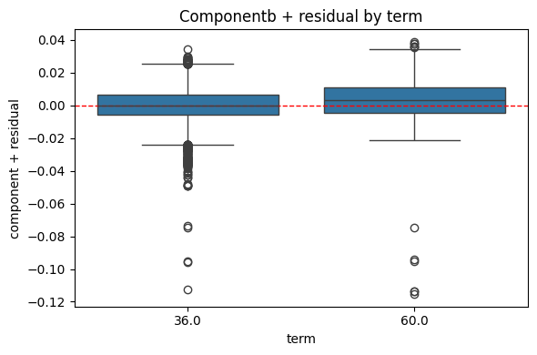

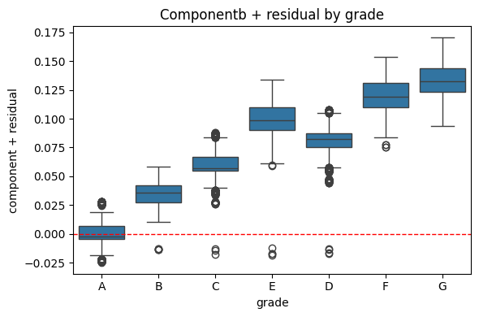

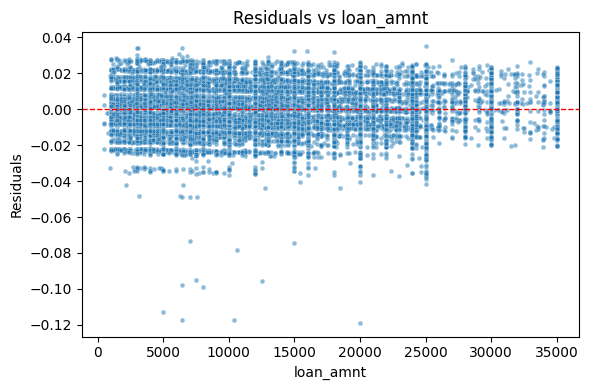

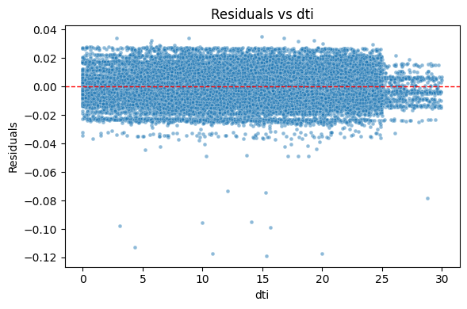

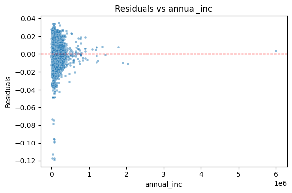

```python
def residual_plots_by_type(model, cats=None, nums=None, sample=None):
    """
    Make residual diagnostics:
      - Categorical predictors: boxplots of (component + residual) for the factor
      - Numeric predictors: scatter of residuals vs predictor

    Parameters
    ----------
    model : statsmodels.regression.linear_model.RegressionResultsWrapper
        Fitted OLS (formula API recommended so model.model.data.frame exists).
    cats : list[str] | None
        Categorical variables to plot. If None, auto-detect (C(var) in design).
    nums : list[str] | None
        Numeric variables to plot. If None, auto-detect plain numeric columns used.
    sample : int | None
        If set, downsample numeric scatters to this many rows for speed/clarity.
    """
    import re
    # Data used in the fit (aligned with residuals)
    df = model.model.data.frame.copy()
    resid = model.resid.values

    # Design matrix + names + params (needed for factor components)
    X = model.model.exog
    xnames = model.model.exog_names
    params = model.params

    # ---- auto-detect categorical factors (by dummy columns like C(fac)[T.level]) ----
    if cats is None:
        pat = re.compile(r"^C\((?P<fac>[^)]+)\)\[T\..+\]$")
        cats = []
        for nm in xnames:
            m = pat.match(nm)
            if m:
                fac = m.group("fac")
                if fac in df.columns and fac not in cats:
                    cats.append(fac)

    # ---- auto-detect numeric predictors present as plain columns in df ----
    if nums is None:
        nums = [
            nm for nm in xnames
            if nm in df.columns
            and nm.lower() not in ("intercept", "const")
            and pd.api.types.is_numeric_dtype(df[nm])
        ]

    # ================== CATEGORICAL: component + residual boxplots ==================
    for fac in cats:
        if fac not in df.columns:
            continue
        # indices of dummy columns belonging to this factor
        fac_cols_idx = [i for i, nm in enumerate(xnames) if nm.startswith(f"C({fac})[T.")]
        if not fac_cols_idx:
            continue  # nothing to plot

        # component for this factor = X_F @ beta_F
        beta_fac = params.iloc[fac_cols_idx].values
        comp_fac = X[:, fac_cols_idx] @ beta_fac
        comp_plus_resid = resid + comp_fac

        tmp = pd.DataFrame({fac: df[fac], "comp_plus_resid": comp_plus_resid})
        plt.figure(figsize=(6, 4))
        sns.boxplot(data=tmp, x=fac, y="comp_plus_resid")
        plt.axhline(0, ls="--", c="red", lw=1)
        plt.title(f"Componentb + residual by {fac}")
        plt.xlabel(fac); plt.ylabel("component + residual")
        plt.tight_layout()
        plt.show()

    # ================== NUMERIC: residual scatter plots ==================
    for v in nums:
        if v not in df.columns:
            continue
        plot_df = df[[v]].copy()
        plot_df["_resid"] = resid
        plot_df = plot_df.dropna()
        if sample is not None and len(plot_df) > sample:
            plot_df = plot_df.sample(sample, random_state=1)

        plt.figure(figsize=(6, 4))
        sns.scatterplot(data=plot_df, x=v, y="_resid", s=12, alpha=0.5)
        plt.axhline(0, ls="--", c="red", lw=1)
        plt.title(f"Residuals vs {v}")
        plt.xlabel(v); plt.ylabel("Residuals")
        plt.tight_layout()
        plt.show()

residual_plots_by_type(model2)
```

## Part 4.3: Out of Sample Testing

For the regression models we’ve just run we used the same dataset to estimate the model and then to test how well the model performs. This is “unfair” in the sense that we are setting up the model to do well – we have chosen the model that does the best in terms of reducing square error in this dataset, which will inevitably lead to problems of overfitting. A natural question will be how would the model perform in a new dataset on which it has not had the chance to train?

To answer this question we can do validation. The idea is to train the model in a subset of data (the training set) and leave behind some data to test the model’s performance (testing set). Because this methods holds out some of the data, it is sometimes referred to as the hold out method of cross validation. Typically, we want the training set to be larger than the testing set as the model needs a lot of data to train but it’s performance can be reliably judged with a smaller dataset.

However, we should note that doing out of sample testing using this method is wasteful as we only train the model on a subset of the data. Also, it may be prone to problems if the training set happens to be different to the testing set by chance.

**Is the out of sample error larger than the in sample error? By how much? Change the random seed and try again.**

```python
# sklearn is the most used library for machine learning tasks in Python
from sklearn.model_selection import train_test_split
from sklearn.metrics import root_mean_squared_error


# 1. Split into training (75%) and testing (25%)
train_df, test_df = train_test_split(df_clean, train_size=0.75, random_state=4444)

# 2. Fit model2 on the training set
model2_train = smf.ols(
    'int_rate ~ loan_amnt + C(term) + dti + annual_inc + C(grade)',
    data=train_df
).fit()

# 3. In-sample RMSE (training residuals)
rmse_training = np.sqrt(np.mean(model2_train.resid**2))

# 4. Predictions on the testing set
pred_test = model2_train.predict(test_df)

# 5. Out-of-sample RMSE
# Out-of-sample RMSE
rmse_testing = root_mean_squared_error(test_df["int_rate"], pred_test)

print(f"RMSE in-sample: {rmse_training:.4f}")
print(f"RMSE out-of-sample: {rmse_testing:.4f}")
increase_pct = ((rmse_testing - rmse_training) / rmse_training) * 100
print(f"Relative increase in error: {increase_pct:.2f}%")
```

```
RMSE in-sample: 0.0105
RMSE out-of-sample: 0.0106
Relative increase in error: 0.31%
```

## Part 5: Sample size estimation

One question that every data scientist should worry about is whether the dataset they are working with is large enough to generate reliable results for the model they are trying to estimate. In general, the larger the better as the coefficients will be estimated with more accuracy. But as with most things in statistics, there are diminishing returns to size – if the data is large enough then increasing the data set is no longer a priority. How do you know what what is enough? Let’s investigate this.

One way of doing this is by creating a fixed testing set that contains say 25% of the data. From the remaining 75% of the data, we will select a training set of size N:

- We will start with really small N, estimate the model in this small training set and the see how well it does out of sample in the training set by measuring the RMSE of the predictions.
- As N increases the model estimation will become more reliable and we expect the root mean square error (RMSE) of out of sample predictions to decrease and the out of sample R-square to increase.
- For some N large enough, there will be little further gains from increasing N. In other words, to continue improving the performance of the model collecting more rows of the same features will not help. Instead we will need more features / more columns! Can you identify this N for the model we trained above?

In general, this will depend on how much variability there is in the data (both the dependent variable and the features) and how many features there are in the model.

**Question: How large a dataset is enough to estimate model 2?**

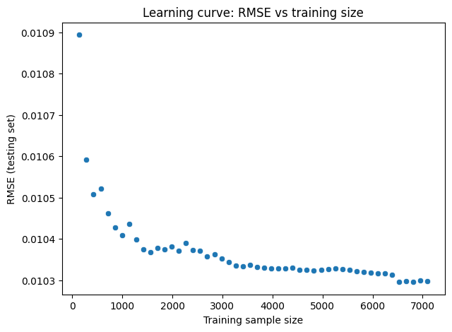

```python
from sklearn.metrics import r2_score


# 1. Split once: 75% remaining pool, 25% fixed testing set
train_pool, test_df = train_test_split(df_clean, train_size=0.75, random_state=102)

# 2. Storage for results
rmse_sample = []
rsq_sample = []
sample_size = []

# 3. Loop over different training sizes
for i in range(1, 51):
    # training proportion increases from 0.5% up to ~25%
    train_size_prop = 0.005 + (i-1)/200

    # Subsample from the pool
    train_sub, _ = train_test_split(train_pool, train_size=train_size_prop, random_state=101)

    sample_size.append(len(train_sub))

    # Fit model on this subsample
    model = smf.ols(
        'int_rate ~ loan_amnt + C(term) + dti + annual_inc + C(grade)',
        data=train_sub
    ).fit()

    # Predict on the fixed testing set
    preds = model.predict(test_df)

    # Compute metrics
    rmse_sample.append(root_mean_squared_error(test_df["int_rate"], preds))
    rsq_sample.append(r2_score(test_df["int_rate"], preds))

# 4. Pack into a DataFrame
results = pd.DataFrame({
    "sample_size": sample_size,
    "rmse_sample": rmse_sample,
    "rsq_sample": rsq_sample
})

# 5. Plot RMSE vs sample size
plt.figure(figsize=(7,5))
sns.scatterplot(data=results, x="sample_size", y="rmse_sample")
plt.xlabel("Training sample size")
plt.ylabel("RMSE (testing set)")
plt.title("Learning curve: RMSE vs training size")
plt.show()
```

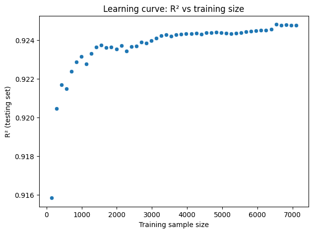

```python
# Plot R² vs sample size
plt.figure(figsize=(7,5))
sns.scatterplot(data=results, x="sample_size", y="rsq_sample")
plt.xlabel("Training sample size")
plt.ylabel("R² (testing set)")
plt.title("Learning curve: R² vs training size")
plt.show()
```

## Part 6: K-fold Cross Validation

The problem with the out of sample validation method we used before is that it only estimates the model once using one randomly chosen subset of data (the training set). What if we were unlucky when we chose that dataset and for whatever reason it’s not representative of reality? Also, by estimating the model on a subset of the data we don’t make use of all of the information available.

To overcome this concern, we could repeat the process of choosing a training and a validation set. The k-fold validation method does this by splitting the data into k subsamples (also called folds) of equal size. It then estimates the model k times. Each time one of the k sets is the testing set and the other k-1 sets form the training set on which the model is estimated. It then reports the out of sample performance of the model as the average of these k out of sample validations. Finally, it trains the model one last time on all data to make use of all of the information.

Typically we choose 5-10 folds. The more folds the longer it takes to run (as we need to run the model k+1 times) but the more accurate the results become. Can you think of a method to figure out how large k should be?

```python
from sklearn.model_selection import KFold

# --- 1) Define CV splitter ---
k = 10
kf = KFold(n_splits=k, shuffle=True, random_state=4444)
# The splits of the dataset are random-like, if you use the same random_state you will however always
# get the same splits (for reproducibility)
# You can change the random_state and the splits will change!

rmse_scores, r2_scores = [], []

# --- 2) Loop over folds with explicit progress printouts ---
for fold, (train_idx, test_idx) in enumerate(kf.split(df_clean), start=1):
    train_df = df_clean.iloc[train_idx]
    test_df  = df_clean.iloc[test_idx]

    model = smf.ols("int_rate ~ loan_amnt + C(term) + dti + annual_inc + C(grade)", data=train_df).fit()
    preds = model.predict(test_df)

    rmse = root_mean_squared_error(test_df["int_rate"], preds)
    r2   = r2_score(test_df["int_rate"], preds)

    rmse_scores.append(rmse)
    r2_scores.append(r2)

    print(f"Fold {fold:2d}/{k}  |  n_train={len(train_df):5d}  n_test={len(test_df):5d}  "
          f"RMSE={rmse:.4f}  R²={r2:.4f}")

# --- 3) Summaries across folds ---
print("\n=== 10-fold CV summary ===")
print(f"RMSE: mean={np.mean(rmse_scores):.4f}, sd={np.std(rmse_scores):.4f}, "
      f"min={np.min(rmse_scores):.4f}, max={np.max(rmse_scores):.4f}")
print(f"R²:   mean={np.mean(r2_scores):.4f}, sd={np.std(r2_scores):.4f}, "
      f"min={np.min(r2_scores):.4f}, max={np.max(r2_scores):.4f}")


model = smf.ols("int_rate ~ loan_amnt + C(term) + dti + annual_inc + C(grade)", data=df_clean).fit()
print(model4.summary())
```

```
Fold  1/10  |  n_train=34082  n_test= 3787  RMSE=0.0104  R²=0.9236
Fold  2/10  |  n_train=34082  n_test= 3787  RMSE=0.0104  R²=0.9231
Fold  3/10  |  n_train=34082  n_test= 3787  RMSE=0.0110  R²=0.9139
Fold  4/10  |  n_train=34082  n_test= 3787  RMSE=0.0102  R²=0.9249
Fold  5/10  |  n_train=34082  n_test= 3787  RMSE=0.0105  R²=0.9232
Fold  6/10  |  n_train=34082  n_test= 3787  RMSE=0.0109  R²=0.9134
Fold  7/10  |  n_train=34082  n_test= 3787  RMSE=0.0108  R²=0.9135
Fold  8/10  |  n_train=34082  n_test= 3787  RMSE=0.0104  R²=0.9216
Fold  9/10  |  n_train=34082  n_test= 3787  RMSE=0.0105  R²=0.9210
Fold 10/10  |  n_train=34083  n_test= 3786  RMSE=0.0103  R²=0.9182

=== 10-fold CV summary ===
RMSE: mean=0.0106, sd=0.0002, min=0.0102, max=0.0110
R²:   mean=0.9196, sd=0.0043, min=0.9134, max=0.9249
                            OLS Regression Results
==============================================================================
Dep. Variable:               int_rate   R-squared:                       0.922
Model:                            OLS   Adj. R-squared:                  0.922
Method:                 Least Squares   F-statistic:                 1.949e+04
Date:                Wed, 30 Sep 2026   Prob (F-statistic):               0.00
Time:                        19:54:04   Log-Likelihood:             1.1918e+05
No. Observations:               37869   AIC:                        -2.383e+05
Df Residuals:                   37845   BIC:                        -2.381e+05
Df Model:                          23
Covariance Type:            nonrobust
=================================================================================================
                                    coef    std err          t      P>|t|      [0.025      0.975]
-------------------------------------------------------------------------------------------------
Intercept                         0.0725      0.000    292.676      0.000       0.072       0.073
C(grade)[T.B]                     0.0366      0.000    134.396      0.000       0.036       0.037
C(grade)[T.C]                     0.0622      0.000    209.383      0.000       0.062       0.063
C(grade)[T.D]                     0.0803      0.000    227.707      0.000       0.080       0.081
C(grade)[T.E]                     0.0942      0.001    182.244      0.000       0.093       0.095
C(grade)[T.F]                     0.1091      0.001    117.183      0.000       0.107       0.111
C(grade)[T.G]                     0.1283      0.002     68.822      0.000       0.125       0.132
C(term)[T.60.0]                   0.0021      0.001      3.934      0.000       0.001       0.003
C(term)[T.60.0]:C(grade)[T.B]    -0.0020      0.001     -3.439      0.001      -0.003      -0.001
C(term)[T.60.0]:C(grade)[T.C]     0.0001      0.001      0.180      0.857      -0.001       0.001
C(term)[T.60.0]:C(grade)[T.D]     0.0059      0.001      9.574      0.000       0.005       0.007
C(term)[T.60.0]:C(grade)[T.E]     0.0074      0.001     10.717      0.000       0.006       0.009
```

[output cut: 8 more lines]

```
loan_amnt:C(grade)[T.G]       -3.262e-08   7.36e-08     -0.444      0.657   -1.77e-07    1.12e-07
I(loan_amnt ** 2)              6.612e-12   8.02e-13      8.245      0.000    5.04e-12    8.18e-12
dti                            4.107e-05   8.17e-06      5.025      0.000    2.51e-05    5.71e-05
annual_inc                    -1.364e-09   9.15e-10     -1.490      0.136   -3.16e-09     4.3e-10
==============================================================================
Omnibus:                     2652.510   Durbin-Watson:                   0.128
Prob(Omnibus):                  0.000   Jarque-Bera (JB):            11077.860
Skew:                          -0.230   Prob(JB):                         0.00
Kurtosis:                       5.609   Cond. No.                     1.23e+10
==============================================================================

Notes:
[1] Standard Errors assume that the covariance matrix of the errors is correctly specified.
[2] The condition number is large, 1.23e+10. This might indicate that there are
strong multicollinearity or other numerical problems.
```

## Part 7: Feature Importance

Not all features have the same explanatory power. Some are more helpful in explaining the variation of the dependent variable. These features will be more helpful in forecasting.

Below we present a visual investigation of the relative importance of different variables.

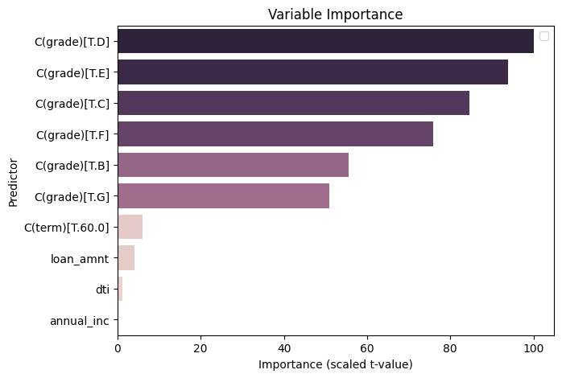

```python
# Collect t-values (exclude intercept)
tvals = model2.tvalues.drop(labels=["Intercept"], errors="ignore").abs()
importance = 100 * tvals / tvals.max()
importance = importance.sort_values(ascending=False)

# Plot
plt.figure(figsize=(7,5))
sns.barplot(x=importance.values, y=importance.index, hue=importance.values)
plt.xlabel("Importance (scaled t-value)")
plt.ylabel("Predictor")
plt.title("Variable Importance")
plt.legend([])
plt.show()
```

## Part 8: Automated feature selection and stepwise regression

As the number of features available increases it becomes important to only select the subset of features that have real explanatory power out of sample. Including features without real explanatory power is not helpful (in fact it may be harmful because the model will be more prone to problems of overfitting) and it may be costly as someone needs to collect, store, and validate additional data.

It is tempting to just include all the features with the most explanatory power. And if the features were uncorrelated with each other this would work. But in a world where features are correlated with each other it is difficult if not impossible to know which combination of features will work the best (i.e., have the most out of sample predictive power) without trying.

```python
### The smf package for OLS problems does not feature an automatic stepwise regression routine.
### scikit-learn, on the contrary, does but we want to keep the linear regression modelling similar to the previous part of the notebook
### Below you can find a few custom-made functions that perform backward_selection starting from the formula of the OLS model
def backward_selection_cv_columns(
    full_formula: str,
    data: pd.DataFrame,
    k: int = 5,
    nv_range: tuple[int, int] | None = None,   # e.g. (10, 16)
    tol: float = 0.0,
    random_state: int = 4444,
    verbose: bool = True,
):
    """
    Backward elimination guided by k-fold CV RMSE, operating on *design-matrix columns*.

    Parameters
    ----------
    full_formula : str
        e.g. "int_rate ~ loan_amnt + C(term) + dti + annual_inc + C(grade) + loan_amnt:C(grade)"
    data : DataFrame
        Must contain all variables in the formula. 'int_rate' is the outcome.
    k : int
        Number of CV folds.
    nv_range : (lo, hi) | None
        Restrict *column count* (excluding intercept) to [lo, hi] when choosing the final model.
    tol : float
        Required improvement in RMSE to accept a drop (0.0 = accept tie/improvement).
    random_state : int
        Reproducibility for CV splits.
    verbose : bool
        Print progress.

    Returns
    -------
    results_all : DataFrame
        Each accepted step with columns: size (#cols excl. intercept), rmse, sd, cols (list of names).
    results_range : DataFrame
        results_all filtered to nv_range (or same as results_all if nv_range is None/empty).
    best_cols : list[str]
        Names of selected columns (design-matrix level).
    """

    # 1) Build design matrices

    from patsy import dmatrices
    import statsmodels.api as sm
    y, X = dmatrices(full_formula, data, return_type="dataframe")
    colnames = X.columns.tolist()
    has_intercept = "Intercept" in colnames
    cols = [c for c in colnames if c != "Intercept"]

    if verbose:
        print(f"Design matrix has {len(cols)} predictors (excluding intercept).")

    # Inner CV scorer over a chosen subset of columns
    def cv_rmse_for_cols(cols_subset):
        # Keep intercept if present
        use_cols = (["Intercept"] if has_intercept else []) + cols_subset
        Xsub = X[use_cols]

        kf = KFold(n_splits=k, shuffle=True, random_state=random_state)
        rmses = []
        for tr_idx, te_idx in kf.split(Xsub):
            Xtr, Xte = Xsub.iloc[tr_idx], Xsub.iloc[te_idx]
            ytr, yte = y.iloc[tr_idx, 0], y.iloc[te_idx, 0]
            model = sm.OLS(ytr, Xtr).fit()
            preds = model.predict(Xte)
            rmses.append(root_mean_squared_error(yte, preds))
        return float(np.mean(rmses)), float(np.std(rmses))

    # 2) Start from the full set of columns
    current = cols[:]
    best_rmse, best_sd = cv_rmse_for_cols(current)
    history = [{"size": len(current), "rmse": best_rmse, "sd": best_sd, "cols": current.copy()}]
    if verbose:
        print(f"Start: size={len(current)} | CV RMSE={best_rmse:.4f}")

    # 3) Backward loop: drop one column at a time if it improves CV RMSE
    improved = True
    lo = nv_range[0] if nv_range else None

    while improved and len(current) > 1:
        # obey lower bound if provided
        if lo is not None and len(current) <= lo:
            if verbose:
                print(f"Reached lower bound size={lo}; stopping backward elimination.")
            break

        improved = False
        trials = []
        for c in current:
            trial = [x for x in current if x != c]
            rm, sd = cv_rmse_for_cols(trial)
            trials.append((rm, sd, c, trial))
            if verbose:
                print(f"  drop {c:<30} -> CV RMSE={rm:.4f}")

        # pick the drop giving lowest RMSE
        trials.sort(key=lambda z: z[0])
        cand_rm, cand_sd, cand_col, cand_set = trials[0]

        if cand_rm <= best_rmse - tol:
            current = cand_set
            best_rmse, best_sd = cand_rm, cand_sd
            history.append({"size": len(current), "rmse": best_rmse, "sd": best_sd, "cols": current.copy()})
            improved = True
            if verbose:
                print(f"✔ accepted: drop {cand_col} | size={len(current)} | CV RMSE={best_rmse:.4f}")
        else:
            if verbose:
                print("No further CV improvement — stop.")
            break

    results_all = pd.DataFrame(history).sort_values("size").reset_index(drop=True)

    # 4) Choose the best step within nv_range (if provided)
    if nv_range:
        lo, hi = nv_range
        mask = (results_all["size"] >= lo) & (results_all["size"] <= hi)
        results_range = results_all.loc[mask].copy()
        if results_range.empty:
            if verbose:
                print(f"Warning: no models along the backward path have size in [{lo}, {hi}].")
            # fall back to overall best
            best_row = results_all.loc[results_all["rmse"].idxmin()]
        else:
            best_row = results_range.loc[results_range["rmse"].idxmin()]
    else:
        results_range = results_all.copy()
        best_row = results_all.loc[results_all["rmse"].idxmin()]

    best_cols = best_row["cols"]
    return results_all, results_range, best_cols

def final_model_coefs(full_formula, data, best_cols):
    """
    Refit the final OLS model on all data using the best subset of columns
    and return coefficients as a tidy DataFrame (like R's coef()).

    Parameters
    ----------
    full_formula : str
        Full formula string used to generate the design matrix.
    data : DataFrame
        Data containing all variables.
    best_cols : list of str
        Column names (from the design matrix) selected by backward_selection_cv_columns.

    Returns
    -------
    DataFrame
        Columns: Variable, Coefficient
    """
    import statsmodels.api as sm
    from patsy import dmatrices
    # Build design matrices
    y, X = dmatrices(full_formula, data, return_type="dataframe")

    # Ensure intercept is always included if present
    use_cols = (["Intercept"] if "Intercept" in X.columns else []) + best_cols

    # Refit on all data
    fit = sm.OLS(y.iloc[:, 0], X[use_cols]).fit()

    # Pack into a DataFrame
    coef_df = pd.DataFrame({
        "Variable": fit.params.index,
        "Coefficient": fit.params.values
    })

    return coef_df

# Formula for the model
full_formula = "int_rate ~ loan_amnt + C(term) + dti + annual_inc + C(grade) + loan_amnt:C(grade)"
# Ask for models between 10 and 16 *columns* (excluding intercept), like nvmax=10:16
results_all, results_10_16, best_cols = backward_selection_cv_columns(
    full_formula, df_clean, k=5, nv_range=(10,16), verbose=True
)

coef_table = final_model_coefs(full_formula, df_clean, best_cols)
```

```
Design matrix has 16 predictors (excluding intercept).
Start: size=16 | CV RMSE=0.0105
  drop C(term)[T.60.0]                -> CV RMSE=0.0106
  drop C(grade)[T.B]                  -> CV RMSE=0.0127
  drop C(grade)[T.C]                  -> CV RMSE=0.0154
  drop C(grade)[T.D]                  -> CV RMSE=0.0164
  drop C(grade)[T.E]                  -> CV RMSE=0.0154
  drop C(grade)[T.F]                  -> CV RMSE=0.0132
  drop C(grade)[T.G]                  -> CV RMSE=0.0115
  drop loan_amnt                      -> CV RMSE=0.0105
  drop loan_amnt:C(grade)[T.B]        -> CV RMSE=0.0105
  drop loan_amnt:C(grade)[T.C]        -> CV RMSE=0.0105
  drop loan_amnt:C(grade)[T.D]        -> CV RMSE=0.0105
  drop loan_amnt:C(grade)[T.E]        -> CV RMSE=0.0105
  drop loan_amnt:C(grade)[T.F]        -> CV RMSE=0.0105
  drop loan_amnt:C(grade)[T.G]        -> CV RMSE=0.0105
  drop dti                            -> CV RMSE=0.0105
  drop annual_inc                     -> CV RMSE=0.0105
No further CV improvement — stop.
```

```python
print("\nFinal model coefficients:")
print(coef_table)
```

```
Final model coefficients:
                   Variable   Coefficient
0                 Intercept  7.171150e-02
1           C(term)[T.60.0]  3.793070e-03
2             C(grade)[T.B]  3.623288e-02
3             C(grade)[T.C]  6.198462e-02
4             C(grade)[T.D]  8.081671e-02
5             C(grade)[T.E]  9.632893e-02
6             C(grade)[T.F]  1.142522e-01
7             C(grade)[T.G]  1.327265e-01
8                 loan_amnt  1.528433e-07
9   loan_amnt:C(grade)[T.B] -6.616998e-08
10  loan_amnt:C(grade)[T.C] -1.703722e-07
11  loan_amnt:C(grade)[T.D]  6.702686e-08
12  loan_amnt:C(grade)[T.E]  2.208774e-07
13  loan_amnt:C(grade)[T.F]  2.779210e-07
14  loan_amnt:C(grade)[T.G]  1.265103e-07
15                      dti  3.835621e-05
16               annual_inc -1.224270e-09
```

## Part 9: Regularisation using LASSO regression

All methods of choosing between models we have discussed so far relied on estimating a bunch of models using the **Ordinary Least Squares (OLS)** algorithm and then comparing their performance based on some (out-of-sample) performance measure (e.g., RMSE).

As such they are *passive* – if the algorithm overfits the data we find out through out-of-sample testing but we cannot do anything to correct it! An alternative method that tries to actively avoid overfitting is **regularization**. There are two popular regularization methods, **Ridge regression** and **LASSO** (and methods that combine the two called **elastic nets**). They are similar and both produce results that suffer less from overfitting compared to OLS regression especially for small datasets. Here we will focus on **LASSO** which is better suited to models that have a lot of potentially irrelevant features. LASSO stands for *Least Absolute Shrinkage and Selection Operator*.

The main idea is to modify the OLS algorithm so that the estimated model becomes less sensitive to the training set. Remember that OLS minimizes the sum of square errors:

$$ \min_{\beta} \sum_i (y_i - \hat{y}_i)^2 $$

LASSO instead minimizes the sum of square error **plus a penalty** proportional to the sum of the absolute values of the estimated coefficients:

$$ \min_{\beta} \left( \sum_i (y_i - \hat{y}_i)^2 + \lambda \sum_j |\beta_j| \right) $$

By changing the least squares model the estimated coefficients and the predictions become **biased** – therefore you should not use LASSO if your goal is to do inference. But for **predictions**, the bias is something worth tolerating as the model’s predictions become less variable (lower error).

The parameter $\lambda \geq 0$ (pronounced *lambda*) is called a **hyper-parameter** and it is user specified.

- If $\lambda = 0$ the model reduces to the OLS algorithm.
- If $\lambda > 0$ the model penalizes the objective for any coefficient that is different from zero.

Therefore, for a coefficient to be different from zero by 1 unit it needs to reduce the sum of square errors by at least $\lambda$ units. The larger the value of $\lambda$, the more coefficients will be equal to zero (and even those that are not zero will shrink towards zero). Typically, we fit the model multiple times with different values of the hyperparameter $\lambda$ and we select the value of $\lambda$ that generates the lowest out-of-sample error.

Since coefficients of different variables are measured in different units, it is important to **standardize** any continuous variable (subtract the mean and divide by standard deviation). Otherwise results will be misleading!

Unlike linear regression, **LASSO regression** allows us to estimate a model even if we have more parameters to estimate than data points. This is useful in a world of big data (e.g., detecting genes that are associated with specific phenotypes / disease). Furthermore, LASSO allows us to estimate a model even if the features are perfectly correlated with one another (problem of multicollinearity).

Even though the dataset we use is really small, if we choose the value of $\lambda$ carefully, LASSO regression produces reliable out-of-sample results, while the linear regression is unreliable due to problems of overfitting.

*Try changing the seed of the training/testing set – sometimes the results of the linear regression are OK, many times not. You can change the candidate $\lambda$ values to improve the LASSO regression model.*

```
Best lambda (alpha) from 5-fold CV: 0.000319
CV RMSE (mean across folds): 0.010012
```

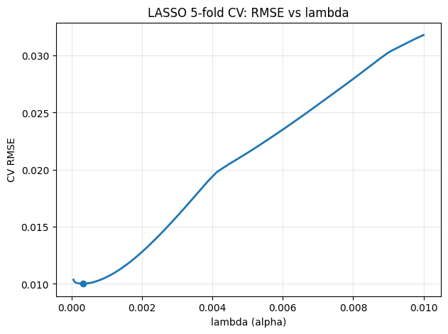

```
Test RMSE (hold-out set): 0.011071
```

```python
# LASSO is a standard feature of the scikit-learn library. Here we perform the linear regression using the "formula" approach as before
# We use the library patsy to transform the formula, together with the original dataset, into a numerical dataset that scikit-learn can process.

from sklearn.model_selection import GridSearchCV
from sklearn.preprocessing import StandardScaler
from sklearn.pipeline import Pipeline
from sklearn.linear_model import Lasso
from sklearn.metrics import make_scorer
from patsy import dmatrices

# 1) Split: training = 1%, testing = 99%
train_df, test_df = train_test_split(df_clean, train_size=0.01, random_state=1234)

# 2) Formula for a big linear regression model
formula = (
    "int_rate ~ loan_amnt + I(loan_amnt**2) + I(loan_amnt**3) "
    "+ C(term) + dti + annual_inc + C(grade) "
    "+ C(grade):(loan_amnt + I(loan_amnt**2) + I(loan_amnt**3)):C(term) "
    "+ (loan_amnt + I(loan_amnt**2) + I(loan_amnt**3)):C(term) "
    "+ C(grade):C(term)"
)


# 3) Build design matrices using patsy to feed scikit-learn routines
y_tr, X_tr = dmatrices(formula, train_df, return_type="dataframe")
y_te, X_te = dmatrices(formula, test_df,  return_type="dataframe")

# Drop intercept column and let Lasso fit its own intercept (unpenalized)
if "Intercept" in X_tr.columns:
    X_tr = X_tr.drop(columns=["Intercept"])
    X_te = X_te.drop(columns=["Intercept"])

# 4) We perform LASSO for multiple lambda values
lambda_seq = np.linspace(0.00005, 0.01, 1001)
alphas = lambda_seq.copy()

# 5) Pipeline: we first standardize the data then perform LASSO
pipe = Pipeline([
    ("scaler", StandardScaler(with_mean=True, with_std=True)),
    ("lasso",  Lasso(max_iter=10000, tol=1e-6, fit_intercept=True))
])

# 6) Define the Cross Validation routine
cv = KFold(n_splits=5, shuffle=True, random_state=4444)

# 7) Define the metric to be assessed at the end of each LASSO experiment
rmse_scorer = make_scorer(root_mean_squared_error, greater_is_better=False)

#8) Performing the Lasso with a grid search on the selected values of lambda + cross validation
grid = GridSearchCV(
    estimator=pipe,
    param_grid={"lasso__alpha": alphas},
    scoring=rmse_scorer,
    cv=cv,
    n_jobs=-1,
    refit=True,
    verbose=0
)

grid.fit(X_tr, y_tr.values.ravel())

best_alpha = grid.best_params_["lasso__alpha"]
cv_rmse = -grid.best_score_
print(f"Best lambda (alpha) from 5-fold CV: {best_alpha:.6f}")
print(f"CV RMSE (mean across folds): {cv_rmse:.6f}")

# Plot CV curve
mean_rmse = -grid.cv_results_["mean_test_score"]
alpha_vals = grid.cv_results_["param_lasso__alpha"].data.astype(float)

plt.figure(figsize=(7,5))
plt.plot(alpha_vals, mean_rmse, lw=2)
plt.scatter([best_alpha], [cv_rmse], zorder=3)
plt.xlabel("lambda (alpha)")
plt.ylabel("CV RMSE")
plt.title("LASSO 5-fold CV: RMSE vs lambda")
plt.grid(True, alpha=0.3)
plt.show()

# 5) Evaluate on the held-out test set
y_pred_test = grid.predict(X_te)
test_rmse = root_mean_squared_error(y_te, y_pred_test)
print(f"Test RMSE (hold-out set): {test_rmse:.6f}")
```

```python
# ------------------------------------------------------------------
# 1) LASSO: coefficients at best lambda (original, unstandardized scale)
# ------------------------------------------------------------------
best_alpha = grid.best_params_["lasso__alpha"]
print(f"Best lambda (alpha): {best_alpha:g}")

best_est = grid.best_estimator_
scaler = best_est.named_steps["scaler"]
lasso  = best_est.named_steps["lasso"]

# Column names of the design matrix we trained on (we dropped 'Intercept' for LASSO)
feature_names = list(X_tr.columns)

# Coefs learned on standardized X
beta_std = lasso.coef_.copy()
b0_std   = lasso.intercept_

# Convert back to original X scale:
beta_orig = beta_std / scaler.scale_
b0_orig   = b0_std - np.sum(beta_std * scaler.mean_ / scaler.scale_)

lasso_coef_df = pd.DataFrame({
    "Variable": ["Intercept"] + feature_names,
    "Coefficient": [b0_orig] + list(beta_orig)
})
print("\nLASSO coefficients (original scale):")
print(lasso_coef_df)
```

```
Best lambda (alpha): 0.00031865

LASSO coefficients (original scale):
                                         Variable   Coefficient
0                                       Intercept  7.413485e-02
1                                 C(term)[T.60.0]  5.382731e-03
2                                   C(grade)[T.B]  3.069354e-02
3                                   C(grade)[T.C]  5.568590e-02
4                                   C(grade)[T.D]  7.406113e-02
5                                   C(grade)[T.E]  9.588619e-02
6                                   C(grade)[T.F]  9.245420e-02
7                                   C(grade)[T.G]  1.131489e-01
8                   C(grade)[T.B]:C(term)[T.60.0]  0.000000e+00
9                   C(grade)[T.C]:C(term)[T.60.0] -0.000000e+00
10                  C(grade)[T.D]:C(term)[T.60.0]  0.000000e+00
```

[output cut: 47 more lines]

```python
# Count non-zero vs zero coefficients in the LASSO model
nonzero_mask = np.abs(beta_orig) > 0
n_nonzero = int(nonzero_mask.sum())
n_zero    = int(len(beta_orig) - n_nonzero)
print(f"\n Number of non-zero coefficients (excluding intercept): {n_nonzero}")
print(f" Number of zero coefficients (excluding intercept):    {n_zero}")
```

```
 Number of non-zero coefficients (excluding intercept): 17
 Number of zero coefficients (excluding intercept):    40
```

```python
# ------------------------------------------------------------------
# 2) LASSO: predictions on held-out testing set + performance
# ------------------------------------------------------------------
y_pred_lasso = grid.predict(X_te)
rmse_lasso   = root_mean_squared_error(y_te, y_pred_lasso)
r2_lasso     = r2_score(y_te, y_pred_lasso)

LASSO_results = pd.DataFrame({
    "RMSE":   [rmse_lasso],
    "Rsquare":[r2_lasso]
})
print("\nLASSO_results")
print(LASSO_results)
```

```
LASSO_results
       RMSE   Rsquare
0  0.011071  0.911617
```

```python
# ------------------------------------------------------------------
# 3) OLS with the SAME formula on the same train/test split
# ------------------------------------------------------------------
ols_model = smf.ols(formula, data=train_df).fit()
y_pred_ols = ols_model.predict(test_df)
ols_rmse = root_mean_squared_error(test_df["int_rate"], y_pred_ols)
ols_r2   = r2_score(test_df["int_rate"], y_pred_ols)
OLS_results = pd.DataFrame({"RMSE":[ols_rmse], "Rsquare":[ols_r2]})
print("\nOLS_results")
print(OLS_results)
```

```
OLS_results
       RMSE   Rsquare
0  0.036653  0.031176
```

### Ridge Regression

This is an alternative to Lasso regularisation. Ridge regression tries to penalise the situation where too many parameters are present in the model but it **cannot** set the parameters to zero (as opposed to Lasso). The regularisation derives from a minimisation of the loss function

$$ \min_{\beta} \left( \sum_i (y_i - \hat{y}_i)^2 + \alpha \sum_j \beta_j^2 \right) $$

Note that now the parameters are squared, $\beta_j^2$, rather than taken in absolute value, $|\beta_j|$. The code to perform Ridge regression + K-fold validation is very similar to the Lasso regression above! The hyper-parameter $\alpha$ for the Ridge regression has a similar interpretation to the hyper-parameter for the Lasso regression.

```
Best $lpha$ from 5-fold CV: 5.304735
CV RMSE (mean across folds): 0.105103
```

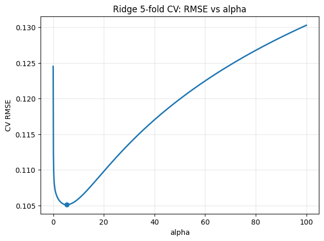

```
Test RMSE (hold-out set): 0.111294
```

```python
from sklearn.linear_model import Ridge

# 1) Split: training = 1%, testing = 99%
train_df, test_df = train_test_split(df_clean, train_size=0.01, random_state=1234)

# 2) Formula for a big linear regression model
formula = (
    "int_rate ~ loan_amnt + I(loan_amnt**2) + I(loan_amnt**3) "
    "+ C(term) + dti + annual_inc + C(grade) "
    "+ C(grade):(loan_amnt + I(loan_amnt**2) + I(loan_amnt**3)):C(term) "
    "+ (loan_amnt + I(loan_amnt**2) + I(loan_amnt**3)):C(term) "
    "+ C(grade):C(term)"
)

# 3) Build design matrices using patsy to feed scikit-learn routines
y_tr, X_tr = dmatrices(formula, train_df, return_type="dataframe")
y_te, X_te = dmatrices(formula, test_df,  return_type="dataframe")

# Drop intercept column and let Lasso fit its own intercept (unpenalized)
if "Intercept" in X_tr.columns:
    X_tr = X_tr.drop(columns=["Intercept"])
    X_te = X_te.drop(columns=["Intercept"])


# 3) We perform Ridge for multiple values of alpha — identical style to LASSO session
alpha_grid = np.linspace(0.005, 100, 1001)

# 4) Pipeline: Standardize then Ridge
pipe = Pipeline([
    ("scaler", StandardScaler(with_mean=True, with_std=True)),
    ("ridge",  Ridge(max_iter=10000, tol=1e-6, fit_intercept=True, solver="auto"))
])

# 5) 5-fold CV (fixed seed)
cv = KFold(n_splits=5, shuffle=True, random_state=4444)

# 6) RMSE scorer
def rmse_metric(y_true, y_pred):
    return np.sqrt(root_mean_squared_error(y_true, y_pred))
rmse_scorer = make_scorer(rmse_metric, greater_is_better=False)

# 7) Grid search over alpha with CV
grid = GridSearchCV(
    estimator=pipe,
    param_grid={"ridge__alpha": alpha_grid},
    scoring=rmse_scorer,
    cv=cv,
    n_jobs=-1,
    refit=True,
    verbose=0
)
grid.fit(X_tr, y_tr.values.ravel())

best_alpha = float(grid.best_params_["ridge__alpha"])
cv_rmse = -grid.best_score_
print(f"Best $\alpha$ from 5-fold CV: {best_alpha:.6f}")
print(f"CV RMSE (mean across folds): {cv_rmse:.6f}")

# Plot CV curve
mean_rmse = -grid.cv_results_["mean_test_score"]
alpha_vals = grid.cv_results_["param_ridge__alpha"].data.astype(float)

plt.figure(figsize=(7,5))
plt.plot(alpha_vals, mean_rmse, lw=2)
plt.scatter([best_alpha], [cv_rmse], zorder=3)
plt.xlabel("alpha")
plt.ylabel("CV RMSE")
plt.title("Ridge 5-fold CV: RMSE vs alpha")
plt.grid(True, alpha=0.3)
plt.show()

# 8) Hold-out evaluation on test set
y_pred_test = grid.predict(X_te)
test_rmse = rmse_metric(y_te, y_pred_test)
print(f"Test RMSE (hold-out set): {test_rmse:.6f}")
```